# 4. Alpha Diversity

# 1 INFO

This Rmarkdown contains the commands necessary to perform alpha diversity analysis of the output from the [DF_GMH_PIPELINE](https://github.com/MSMortensen/DF_GMH_pipeline). It is expected that the data has been imported, cleaned, and saved following the script **1_Import.Rmd** prior to using this script. It is recommend to visiting the [“Analysis of community ecology data in R”](https://www.davidzeleny.net/anadat-r/doku.php/en:start) to read about the theory behind the alpha and beta diversity and examples of the necessary R-code to execute them. Other excellent source of help is the R [cheat-sheets](https://www.rstudio.com/resources/cheatsheets/) and for problems related to Rmarkdown this resource is suggested [online Book](https://bookdown.org/yihui/rmarkdown/).

Alpha diversity, also called “within sample diversity” is calculated for each sample individually and is independent of all other samples. Alpha diversity is sensitive to sequencing depth, so rarefaction must be done first. Here we calculate index: - Observed richness (observed species) - Shannon diversity index - Pielou’s Evenness (not included in final analysis as it is covered by Shannon diversity index) - Faith’s Phylogenetic Diversity

# 2 SETUP

```r
knitr::opts_chunk$set(echo = TRUE)

# Load libraries
library(tidyverse)
library(phyloseq)
library(ggpubr)
library(rstatix)
library(kableExtra)
library(picante)
library(plotly)
library(cowplot)

# Save params
saveRDS(params, file = "R_objects/Adiv_params.RDS")
```

# 3 SCRIPTS

```r
adiv_batch_effect <- function(INNER.VAR, OUTER.VAR, MTRL, DAY) {
  load(params$input)
  adat <- data.frame(sample_data(phy))
  adat <- adat[adat$material == MTRL & adat$day == DAY,]

  # Remove samples with incomplete metadata
  adat <- adat[!is.na(adat[,INNER.VAR]) & !is.na(adat[,OUTER.VAR]),]
  adat[,OUTER.VAR] <- as.factor(adat[,OUTER.VAR])
  adat[,INNER.VAR] <- as.factor(adat[,INNER.VAR])

  # Determine if any batch effect might influence your data
  ## Calculate distribution counts
  freq.t <- with(adat, table(get(params$batch), feed, exclude = NULL))
  freq.t

  ## Determine distribution percentages
  pct.freq.t <- prop.table(freq.t,2)*100

  ## Test if any difference is significant (if not significant the batch effect should be negligible)
  chisq <- chisq_test(freq.t)
  output <- list(freq.t, pct.freq.t, chisq)
  output
  return(output)
}

# Process alpha divertsity data for a material and day and create combined plot with wilcoxon statistics
adiv_output <- function(INNER.VAR, OUTER.VAR, MTRL, DAY) {
  load(params$input)
  adat <- data.frame(sample_data(phy))
  adat <- adat[adat$material == MTRL & adat$day == DAY,]

  # Remove samples with incomplete metadata
  adat <- adat[!is.na(adat[,INNER.VAR]) & !is.na(adat[,OUTER.VAR]),]
  adat[,OUTER.VAR] <- as.factor(adat[,OUTER.VAR])
  adat[,INNER.VAR] <- as.factor(adat[,INNER.VAR])

  INDECES <- c("Observed","Evenness","Shannon","FaithPD")

  #### Test project variable
  for (i in INDECES) {
      fit <- aov(as.formula(paste(i, "~", OUTER.VAR,"*",INNER.VAR, sep = " ")), data = adat)
      aov <- anova(fit)
      thsd <- TukeyHSD(fit)

      ## Calculate stats for inner variable
      # Perform pairwise comparisons
      stat.test <- adat %>%
        group_by(.data[[OUTER.VAR]]) %>%
        wilcox_test(as.formula(paste(i, "~", INNER.VAR, sep = " "))) %>%
        adjust_pvalue(method = "BH") %>%
        add_significance("p.adj") %>%
        add_xy_position(x = OUTER.VAR, dodge = 0.8) %>%
        p_format("p.adj", accuracy = 0.0001, trailing.zero = TRUE, new.col = TRUE)

      ## Calculate stats for outer variable
      # Perform pairwise comparisons
      stat.test2 <- adat %>%
        wilcox_test(as.formula(paste(i,"~", OUTER.VAR, sep = " "))) %>%
        adjust_pvalue(method = "BH") %>%
        add_significance("p.adj") %>%
        add_xy_position(x = OUTER.VAR) %>%
        p_format("p.adj", accuracy = 0.0001, trailing.zero = TRUE, new.col = TRUE)

      print(stat.test)
      print(stat.test2)

      # Adjust y value for outer p-values
      stat.test2$y.position <- max(stat.test$y.position)*1.1

      # Create plot
      p <- ggboxplot(adat, x = OUTER.VAR, y = i,
                color = INNER.VAR,
                fill = INNER.VAR,
                add = "jitter",
                add.params = list(size = 1)) +
        scale_fill_manual(values = params$COL, name = "Group", labels = c("HF_CTRL" = "HF-CTRL","HF_PFOS" = "HF-PFOS","LF_CTRL" = "LF-CTRL","LF_PFOS" = "LF-PFOS")) +
        scale_color_manual(values = c("black","black","black","black")) +
        guides(color = "none") +
        theme(axis.title.x = element_blank())

      # Add p-values
      if (i == "Observed") {
        p.obs <- p + stat_pvalue_manual(stat.test, label = "p.adj.signif",tip.length = 0, hide.ns = TRUE, color = "red")
        p.obs <- p.obs + stat_pvalue_manual(stat.test2, label = "p.adj.signif",tip.length = 0, step.increase = 0.1, hide.ns = TRUE)
        obs <- list(fit = fit, ANOVA = aov, TukeyHSD = thsd)
      } else if (i == "Evenness") {
        p.eve <- p + stat_pvalue_manual(stat.test, label = "p.adj.signif",tip.length = 0, hide.ns = TRUE, color = "red")
        p.eve <- p.eve + stat_pvalue_manual(stat.test2, label = "p.adj.signif",tip.length = 0, step.increase = 0.1, hide.ns = TRUE)
        eve <- list(fit = fit, ANOVA = aov, TukeyHSD = thsd)
      } else if (i == "Shannon") {
        p.sha <- p + stat_pvalue_manual(stat.test, label = "p.adj.signif",tip.length = 0, hide.ns = TRUE, color = "red")
        p.sha <- p.sha + stat_pvalue_manual(stat.test2, label = "p.adj.signif",tip.length = 0, step.increase = 0.1, hide.ns = TRUE)
        sha <- list(fit = fit, ANOVA = aov, TukeyHSD = thsd)
      } else if (i == "FaithPD") {
        p.fpd <- p + stat_pvalue_manual(stat.test, label = "p.adj.signif",tip.length = 0, hide.ns = TRUE, color = "red")
        p.fpd <- p.fpd + stat_pvalue_manual(stat.test2, label = "p.adj.signif",tip.length = 0, step.increase = 0.1, hide.ns = TRUE)
        fph <- list(fit = fit, ANOVA = aov, TukeyHSD = thsd)
      }
  }
      adiv.plot <- ggarrange(p.obs,p.eve,p.sha,p.fpd, nrow = 1, labels = c("A)","B)","C)","D)"), common.legend = TRUE,legend = "top")
      adiv.plot

      save(p.obs,p.eve,p.sha,p.fpd, file = paste0("plots/adiv/alpha_",DAY,"/adiv_",MTRL,"_",DAY,".Rdata"))

      suppressMessages(ggsave(filename = paste0("plots/adiv/alpha_",DAY,"/adiv_",MTRL,"_",DAY,"_nested.png"), plot = adiv.plot, device = "png", units = "mm", width = 350, height = 100, dpi = 300))
      suppressMessages(ggsave(filename = paste0("plots/adiv/alpha_",DAY,"/adiv_",MTRL,"_",DAY,"_nested.pdf"), plot = adiv.plot, device = "pdf", units = "mm", width = 350, height = 100, dpi = 300))

      return(list(plot = adiv.plot, Observed = obs, Evenness = eve, Shannon = sha, FaithPH = fph))
}


adiv_day <- function(INNER.VAR, OUTER.VAR, MTRL, DAY) {
  load(params$input)
  adat <- data.frame(sample_data(phy))
  adat <- adat[adat$material == MTRL & adat$day == DAY,]

  # Remove samples with incomplete metadata
  adat <- adat[!is.na(adat[,INNER.VAR]) & !is.na(adat[,OUTER.VAR]),]
  adat[,OUTER.VAR] <- as.factor(adat[,OUTER.VAR])
  adat[,INNER.VAR] <- as.factor(adat[,INNER.VAR])


  ### Observed richness
  fit <- aov(as.formula(paste("Observed ~", OUTER.VAR,"*",INNER.VAR, sep = " ")), data = adat)
  anova(fit)
  TukeyHSD(fit)

  ## Calculate stats for inner variable
  # Perform pairwise comparisons
  stat.test <- adat %>%
    group_by(.data[[OUTER.VAR]]) %>%
    wilcox_test(as.formula(paste("Observed ~", INNER.VAR, sep = " "))) %>%
    adjust_pvalue(method = "BH") %>%
    add_significance("p.adj") %>%
    add_xy_position(x = OUTER.VAR, dodge = 0.8) %>%
    p_format("p.adj", accuracy = 0.0001, trailing.zero = TRUE, new.col = TRUE)
```

```r
  ## Calculate stats for outer variable
  # Perform pairwise comparisons
  stat.test2 <- adat %>%
    wilcox_test(as.formula(paste("Observed ~", OUTER.VAR, sep = " "))) %>%
    adjust_pvalue(method = "BH") %>%
    add_significance("p.adj") %>%
    add_xy_position(x = OUTER.VAR) %>%
    p_format("p.adj", accuracy = 0.0001, trailing.zero = TRUE, new.col = TRUE)

  # Adjust y value for outer p-values
  stat.test2$y.position <- max(stat.test$y.position)*1.1

  # Create plot
  p <- ggboxplot(adat, x = OUTER.VAR, y = "Observed",
            color = INNER.VAR,
            fill = INNER.VAR,
            add = "jitter",
            add.params = list(size = 1)) +
    scale_fill_manual(values = params$COL, name = "Group", labels = c("HF_CTRL" = "HF-CTRL","HF_PFOS" = "HF-PFOS","LF_CTRL" = "LF-CTRL","LF_PFOS" = "LF-PFOS")) +
    scale_color_manual(values = c("black","black","black","black")) +
    guides(color = "none") +
    theme(axis.title.x = element_blank())

  # Add p-values
  p.obs <- p + stat_pvalue_manual(stat.test, label = "p.adj.format",tip.length = 0, color = "red", hide.ns = TRUE)
  p.obs <- p.obs + stat_pvalue_manual(stat.test2, label = "p.adj.format",tip.length = 0, step.increase = 0.1, hide.ns = TRUE)

  ### Evenness
  fit <- aov(as.formula(paste("Evenness ~", OUTER.VAR,"*",INNER.VAR, sep = " ")), data = adat)
  anova(fit)
  TukeyHSD(fit)

  ## Calculate stats for inner variable
  # Perform pairwise comparisons
  stat.test <- adat %>%
    group_by(.data[[OUTER.VAR]]) %>%
    wilcox_test(as.formula(paste("Evenness ~", INNER.VAR, sep = " "))) %>%
    adjust_pvalue(method = "BH") %>%
    add_significance("p.adj") %>%
    add_xy_position(x = OUTER.VAR, dodge = 0.8) %>%
    p_format("p.adj", accuracy = 0.0001, trailing.zero = TRUE, new.col = TRUE)

  ## Calculate stats for outer variable
  # Perform pairwise comparisons
  stat.test2 <- adat %>%
    wilcox_test(as.formula(paste("Evenness ~", OUTER.VAR, sep = " "))) %>%
    adjust_pvalue(method = "BH") %>%
    add_significance("p.adj") %>%
    add_xy_position(x = OUTER.VAR) %>%
    p_format("p.adj", accuracy = 0.0001, trailing.zero = TRUE, new.col = TRUE)

  # Adjust y value for outer p-values
  stat.test2$y.position <- max(stat.test$y.position)*1.1

  # Create plot
  p <- ggboxplot(adat, x = OUTER.VAR, y = "Evenness",
            color = INNER.VAR,
            fill = INNER.VAR,
            add = "jitter",
            add.params = list(size = 1)) +
    scale_fill_manual(values = params$COL, name = "Group", labels = c("HF_CTRL" = "HF-CTRL","HF_PFOS" = "HF-PFOS","LF_CTRL" = "LF-CTRL","LF_PFOS" = "LF-PFOS")) +
    scale_color_manual(values = c("black","black","black","black")) +
    guides(color = "none") +
    theme(axis.title.x = element_blank())
  # Add p-values
  p.eve <- p + stat_pvalue_manual(stat.test, label = "p.adj.format",tip.length = 0, color = "red", hide.ns = TRUE)
  p.eve <- p.eve + stat_pvalue_manual(stat.test2, label = "p.adj.format",tip.length = 0, step.increase = 0.1, hide.ns = TRUE)

  ### Shannon diversity index
  fit <- aov(as.formula(paste("Shannon ~", OUTER.VAR,"*",INNER.VAR, sep = " ")), data = adat)
  anova(fit)
  TukeyHSD(fit)

  ## Calculate stats for inner variable
  # Perform pairwise comparisons
  stat.test <- adat %>%
    group_by(.data[[OUTER.VAR]]) %>%
    wilcox_test(as.formula(paste("Shannon ~", INNER.VAR, sep = " "))) %>%
    adjust_pvalue(method = "BH") %>%
    add_significance("p.adj") %>%
    add_xy_position(x = OUTER.VAR, dodge = 0.8) %>%
    p_format("p.adj", accuracy = 0.0001, trailing.zero = TRUE, new.col = TRUE)

  ## Calculate stats for outer variable
  # Perform pairwise comparisons
  stat.test2 <- adat %>%
    wilcox_test(as.formula(paste("Shannon ~", OUTER.VAR, sep = " "))) %>%
    adjust_pvalue(method = "BH") %>%
    add_significance("p.adj") %>%
    add_xy_position(x = OUTER.VAR) %>%
    p_format("p.adj", accuracy = 0.0001, trailing.zero = TRUE, new.col = TRUE)

  # Adjust y value for outer p-values
  stat.test2$y.position <- max(stat.test$y.position)*1.1

  # Create plot
  p <- ggboxplot(adat, x = OUTER.VAR, y = "Shannon",
            color = INNER.VAR,
            fill = INNER.VAR,
            add = "jitter",
            add.params = list(size = 1)) +
    scale_fill_manual(values = params$COL, name = "Group", labels = c("HF_CTRL" = "HF-CTRL","HF_PFOS" = "HF-PFOS","LF_CTRL" = "LF-CTRL","LF_PFOS" = "LF-PFOS")) +
    scale_color_manual(values = c("black","black","black","black")) +
    guides(color = "none") +
    theme(axis.title.x = element_blank())
  # Add p-values
  p.sha <- p + stat_pvalue_manual(stat.test, label = "p.adj.format",tip.length = 0, color = "red", hide.ns = TRUE)
  p.sha <- p.sha + stat_pvalue_manual(stat.test2, label = "p.adj.format",tip.length = 0, step.increase = 0.1, hide.ns = TRUE)

  ### FaithPD diversity index
  fit <- aov(as.formula(paste("FaithPD ~", OUTER.VAR,"*",INNER.VAR, sep = " ")), data = adat)
  anova(fit)
  TukeyHSD(fit)

  ## Calculate stats for inner variable
  # Perform pairwise comparisons
  stat.test <- adat %>%
    group_by(.data[[OUTER.VAR]]) %>%
    wilcox_test(as.formula(paste("FaithPD ~", INNER.VAR, sep = " "))) %>%
    adjust_pvalue(method = "BH") %>%
    add_significance("p.adj") %>%
    add_xy_position(x = OUTER.VAR, dodge = 0.8) %>%
    p_format("p.adj", accuracy = 0.0001, trailing.zero = TRUE, new.col = TRUE)

  ## Calculate stats for outer variable
  # Perform pairwise comparisons
  stat.test2 <- adat %>%
    wilcox_test(as.formula(paste("FaithPD ~", OUTER.VAR, sep = " "))) %>%
    adjust_pvalue(method = "BH") %>%
    add_significance("p.adj") %>%
    add_xy_position(x = OUTER.VAR) %>%
    p_format("p.adj", accuracy = 0.0001, trailing.zero = TRUE, new.col = TRUE)

  # Adjust y value for outer p-values
  stat.test2$y.position <- max(stat.test$y.position)*1.1

  # Create plot
  p <- ggboxplot(adat, x = OUTER.VAR, y = "FaithPD",
            color = INNER.VAR,
            fill = INNER.VAR,
            add = "jitter",
            add.params = list(size = 1)) +
    scale_fill_manual(values = params$COL, name = "Group", labels = c("HF_CTRL" = "HF-CTRL","HF_PFOS" = "HF-PFOS","LF_CTRL" = "LF-CTRL","LF_PFOS" = "LF-PFOS")) +
    scale_color_manual(values = c("black","black","black","black")) +
    guides(color = "none") +
    theme(axis.title.x = element_blank())
  # Add p-values
  p.fpd <- p + stat_pvalue_manual(stat.test, label = "p.adj.format",tip.length = 0, color = "red", hide.ns = TRUE)
  p.fpd <- p.fpd + stat_pvalue_manual(stat.test2, label = "p.adj.format",tip.length = 0, step.increase = 0.1, hide.ns = TRUE)
```

```r
    ### Create output plot
  adiv.plot <- ggarrange(p.obs,p.eve,p.sha,p.fpd, nrow = 1, labels = c("A)","B)","C)","D)"), common.legend = TRUE,legend = "top")
  adiv.plot
  suppressMessages(ggsave(filename = paste0("plots/adiv/alpha_",DAY,"/adiv_",MTRL,"_",DAY,"_nested.png"), plot = adiv.plot, device = "png", units = "mm", width = 350, height = 100, dpi = 300))
  suppressMessages(ggsave(filename = paste0("plots/adiv/alpha_",DAY,"/adiv_",MTRL,"_",DAY,"_nested.pdf"), plot = adiv.plot, device = "pdf", units = "mm", width = 350, height = 100, dpi = 300))

  return(adiv.plot)
}

rm_legend <- function(p){p + theme(legend.position = "none")}

save(adiv_day,adiv_batch_effect,adiv_output, rm_legend, file = "scripts/adiv.Rdata")

# clear the environment and release memory
rm(list = ls(all.names = TRUE))
invisible(gc())
```

# 4 BATCH EFFECTS

Before testing any of the project specific variables it is important to determine if there is any batch effects that affect the samples (for example extraction batches or sequencing run)

```r
params <- readRDS("R_objects/Adiv_params.RDS")
# Load data
load("R_objects/Phyloseq.Rdata")
# Extract sample data and alpha diversity
adat <- as_tibble(sample_data(phy))

### Test observed richness
FORMULA <- as.formula(paste("Observed ~", params$batch, sep = " "))
compare_means(FORMULA,  data = adat, method = "kruskal")
```

```
## # A tibble: 1 × 6
##   .y.                  p        p.adj p.format p.signif method
##   <chr>            <dbl>        <dbl> <chr>    <chr>    <chr>
## 1 Observed 0.00000000679 0.0000000068 6.8e-09  ****     Kruskal-Wallis
```

```r
## If significant:
# Perform pairwise comparisons
stat.test <- adat %>%
  wilcox_test(FORMULA) %>%
  adjust_pvalue(method = "BH") %>%
  add_significance("p.adj") %>%
  add_x_position(x = params$batch) %>%
  p_format("p.adj", accuracy = 0.0001, trailing.zero = TRUE, new.col = TRUE)

# Format for
if (sum(stat.test$p.adj.signif != "ns") == 0) {
  stat.sig <- stat.test %>%
    add_y_position(step.increase = 0.25) %>%
    mutate(y.position = seq(min(y.position), max(y.position),length.out = n()))
} else {
  stat.sig <- stat.test[stat.test$p.adj.signif != "ns",] %>%
    add_y_position(step.increase = 0.25) %>%
    mutate(y.position = seq(min(y.position), max(y.position),length.out = n()))
}

# Create plot
p <- ggboxplot(adat, x = params$batch, y = "Observed",
          color = params$batch, palette = "jco",
          add = "jitter")
p.obs <- p + stat_pvalue_manual(stat.sig, label = "p.adj.format",tip.length = 0)


### Test Evenness
FORMULA <- as.formula(paste("Evenness ~", params$batch, sep = " "))
compare_means(FORMULA,  data = adat, method = "kruskal")
```

```
## # A tibble: 1 × 6
##   .y.            p  p.adj p.format p.signif method
##   <chr>      <dbl>  <dbl> <chr>    <chr>    <chr>
## 1 Evenness 0.00412 0.0041 0.0041   **       Kruskal-Wallis
```

```r
## If significant:
# Perform pairwise comparisons
stat.test <- adat %>%
  wilcox_test(FORMULA) %>%
  adjust_pvalue(method = "BH") %>%
  add_significance("p.adj") %>%
  add_x_position(x = params$batch) %>%
  p_format("p.adj", accuracy = 0.0001, trailing.zero = TRUE, new.col = TRUE)

# Format for
if (sum(stat.test$p.adj.signif != "ns") == 0) {
  stat.sig <- stat.test %>%
    add_y_position(step.increase = 0.25) %>%
    mutate(y.position = seq(min(y.position), max(y.position),length.out = n()))
} else {
  stat.sig <- stat.test[stat.test$p.adj.signif != "ns",] %>%
    add_y_position(step.increase = 0.25) %>%
    mutate(y.position = seq(min(y.position), max(y.position),length.out = n()))
}

# Create plot
p <- ggboxplot(adat, x = params$batch, y = "Evenness",
          color = params$batch, palette = "jco",
          add = "jitter")
p.eve <- p + stat_pvalue_manual(stat.sig, label = "p.adj.format",tip.length = 0)

### Test shannon diversity index
# Run statistical test of batch effect
FORMULA <- as.formula(paste("Shannon ~", params$batch, sep = " "))
compare_means(FORMULA,  data = adat, method = "kruskal")
```

```
## # A tibble: 1 × 6
##   .y.            p   p.adj p.format p.signif method
##   <chr>      <dbl>   <dbl> <chr>    <chr>    <chr>
## 1 Shannon 0.000252 0.00025 0.00025  ***      Kruskal-Wallis
```

```r
## If significant:
# Perform pairwise comparisons
stat.test <- adat %>%
  wilcox_test(FORMULA) %>%
  adjust_pvalue(method = "BH") %>%
  add_significance("p.adj") %>%
  add_x_position(x = params$batch) %>%
  p_format("p.adj", accuracy = 0.0001, trailing.zero = TRUE, new.col = TRUE)

# Format for
if (sum(stat.test$p.adj.signif != "ns") == 0) {
  stat.sig <- stat.test %>%
    add_y_position(step.increase = 0.25) %>%
    mutate(y.position = seq(min(y.position), max(y.position),length.out = n()))
} else {
  stat.sig <- stat.test[stat.test$p.adj.signif != "ns",] %>%
    add_y_position(step.increase = 0.25) %>%
    mutate(y.position = seq(min(y.position), max(y.position),length.out = n()))
}

# Create plot
p <- ggboxplot(adat, x = params$batch, y = "Shannon", color = params$batch, palette = "jco", add = "jitter")
p.sdi <- p + stat_pvalue_manual(stat.sig, label = "p.adj.format",tip.length = 0)
# If there is a significant batch effect, then it will be necessary to correct following tests for this effect.

# Test Faith phylogenetic distance
FORMULA <- as.formula(paste("FaithPD ~", params$batch, sep = " "))
compare_means(FORMULA,  data = adat, method = "kruskal")
```

```
## # A tibble: 1 × 6
##   .y.               p      p.adj p.format p.signif method
##   <chr>         <dbl>      <dbl> <chr>    <chr>    <chr>
## 1 FaithPD 0.000000572 0.00000057 5.7e-07  ****     Kruskal-Wallis
```

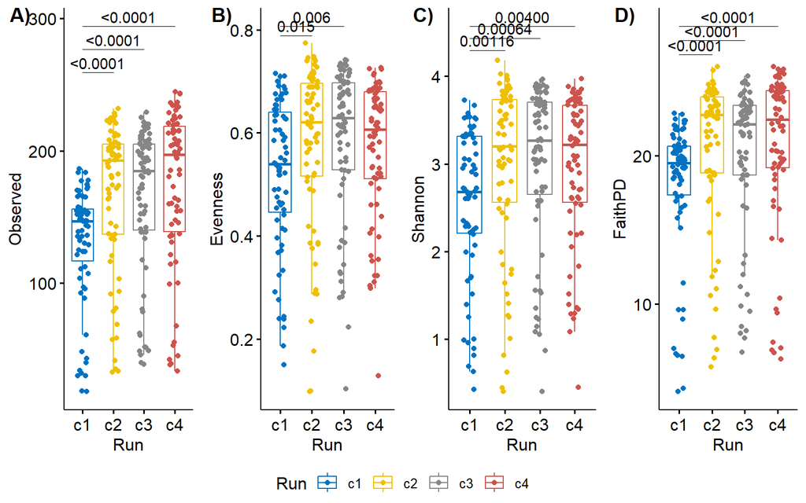

```r
## If significant:
# Perform pairwise comparisons
stat.test <- adat %>%
  wilcox_test(FORMULA) %>%
  adjust_pvalue(method = "BH") %>%
  add_significance("p.adj") %>%
  add_x_position(x = params$batch) %>%
  p_format("p.adj", accuracy = 0.0001, trailing.zero = TRUE, new.col = TRUE)

# Format for
if (sum(stat.test$p.adj.signif != "ns") == 0) {
  stat.sig <- stat.test %>%
    add_y_position(step.increase = 0.25) %>%
    mutate(y.position = seq(min(y.position), max(y.position),length.out = n()))
} else {
  stat.sig <- stat.test[stat.test$p.adj.signif != "ns",] %>%
    add_y_position(step.increase = 0.25) %>%
    mutate(y.position = seq(min(y.position), max(y.position),length.out = n()))
}

# Create plot
p <- ggboxplot(adat, x = params$batch, y = "FaithPD",
          color = params$batch, palette = "jco",
          add = "jitter")
p.fpd <- p + stat_pvalue_manual(stat.sig, label = "p.adj.format",tip.length = 0)

adiv_batch <- ggarrange(p.obs, p.eve, p.sdi, p.fpd, nrow = 1, labels = c("A)","B)","C)","D)"), common.legend = TRUE, legend = "bottom")
suppressMessages(ggsave(filename = "plots/adiv/misc/adiv_batch.png",plot = adiv_batch, device = "png", units = "mm", width = 350, height = 100, dpi = 300))
suppressMessages(ggsave(filename = "plots/adiv/misc/adiv_batch.pdf",plot = adiv_batch, device = "pdf", units = "mm", width = 350, height = 100, dpi = 300))
adiv_batch
```

```r
# clear the environment and release memory
rm(list = ls(all.names = TRUE))
invisible(gc())
```

Boxplot of the influence of sequencing batches on alpha diversity:

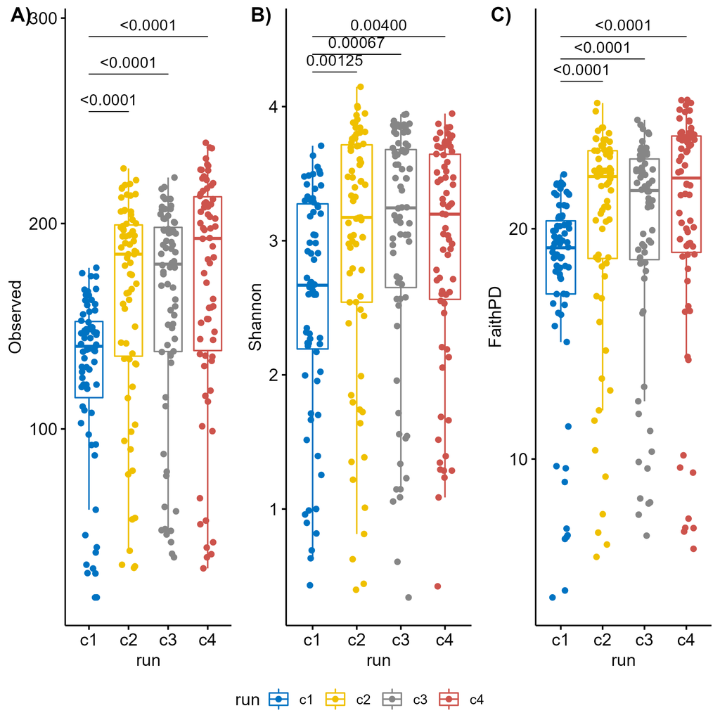

Unfortunately, there is a batch effect between c1 and c2-4. This should be kept in mind for further analysis. However, as all batches are randomized across all samples, part of this effect should be equaled out by random dispersion. It is still important that we determine if any tested variables are independent of the batches or if there is an interaction.

# 5 CATEGORICAL VARIABLES EFFECTS

Keeping in mind possible batch effects, now we can test for project effects. Depending on the project it might be best to test each variable individually or to perform a nested test of the variables. It is important to ensure that R has interpreted the selected variable as a factor, character variables will automatically be interpreted as factors, but variables that consists solely of numbers (numerical or integers) is interpreted as continuous by R and must be transformed to be factors.

## 5.1 Diversity per day (NESTED)

Here we aim to look at diversity differences in each material on each day (0, 8, 12, 16 and 21).

### 5.1.1 Feces day 0

```r
# Load parameters and scripts
params <- readRDS("R_objects/Adiv_params.RDS")
load("scripts/adiv.Rdata")

# Set variables for subset analysis
INNER.VAR <- "feed_treat"
OUTER.VAR <- "feed"
MTRL <- "Feces"
DAY <- "d0"

# Test batch effect for subset
adiv_batch_effect(INNER.VAR, OUTER.VAR, MTRL, DAY)
```

```
## [[1]]
##     feed
##      HF LF
##   c1 11  9
##   c2  7  7
##   c3  2  3
##   c4  4  5
##
## [[2]]
##     feed
##             HF        LF
##   c1 45.833333 37.500000
##   c2 29.166667 29.166667
##   c3  8.333333 12.500000
##   c4 16.666667 20.833333
##
## [[3]]
## # A tibble: 1 × 6
##       n statistic     p    df method          p.signif
## * <int>     <dbl> <dbl> <int> <chr>           <chr>
## 1    48     0.511 0.916     3 Chi-square test ns
```

```
## # A tibble: 2 × 16
##   feed  .y.      group1  group2     n1    n2 statistic     p p.adj p.adj.signif
## * <fct> <chr>    <chr>   <chr>   <int> <int>     <dbl> <dbl> <dbl> <chr>
## 1 HF    Observed HF_CTRL HF_PFOS    12    12        84 0.514 0.514 ns
## 2 LF    Observed LF_CTRL LF_PFOS    12    12        30 0.015 0.03  *
## # ℹ 6 more variables: y.position <dbl>, groups <named list>, x <dbl>,
## #   xmin <dbl>, xmax <dbl>, p.adj.format <chr>
## # A tibble: 1 × 14
##   .y.      group1 group2    n1    n2 statistic           p    p.adj p.adj.signif
## * <chr>    <chr>  <chr>  <int> <int>     <dbl>       <dbl>    <dbl> <chr>
## 1 Observed HF     LF        24    24        67 0.000000983  9.83e-7 ****
## # ℹ 5 more variables: y.position <dbl>, groups <named list>, xmin <dbl>,
## #   xmax <dbl>, p.adj.format <chr>
## # A tibble: 2 × 16
##   feed  .y.      group1  group2     n1    n2 statistic     p p.adj p.adj.signif
## * <fct> <chr>    <chr>   <chr>   <int> <int>     <dbl> <dbl> <dbl> <chr>
## 1 HF    Evenness HF_CTRL HF_PFOS    12    12        67 0.799 0.799 ns
## 2 LF    Evenness LF_CTRL LF_PFOS    12    12        37 0.045 0.09  ns
## # ℹ 6 more variables: y.position <dbl>, groups <named list>, x <dbl>,
## #   xmin <dbl>, xmax <dbl>, p.adj.format <chr>
## # A tibble: 1 × 14
##   .y.      group1 group2    n1    n2 statistic          p     p.adj p.adj.signif
## * <chr>    <chr>  <chr>  <int> <int>     <dbl>      <dbl>     <dbl> <chr>
## 1 Evenness HF     LF        24    24        75 0.00000287   2.87e-6 ****
## # ℹ 5 more variables: y.position <dbl>, groups <named list>, xmin <dbl>,
## #   xmax <dbl>, p.adj.format <chr>
## # A tibble: 2 × 16
##   feed  .y.     group1  group2     n1    n2 statistic     p p.adj p.adj.signif
## * <fct> <chr>   <chr>   <chr>   <int> <int>     <dbl> <dbl> <dbl> <chr>
## 1 HF    Shannon HF_CTRL HF_PFOS    12    12        67 0.799 0.799 ns
## 2 LF    Shannon LF_CTRL LF_PFOS    12    12        32 0.02  0.04  *
## # ℹ 6 more variables: y.position <dbl>, groups <named list>, x <dbl>,
## #   xmin <dbl>, xmax <dbl>, p.adj.format <chr>
## # A tibble: 1 × 14
##   .y.     group1 group2    n1    n2 statistic           p     p.adj p.adj.signif
## * <chr>   <chr>  <chr>  <int> <int>     <dbl>       <dbl>     <dbl> <chr>
## 1 Shannon HF     LF        24    24        62 0.000000483   4.83e-7 ****
## # ℹ 5 more variables: y.position <dbl>, groups <named list>, xmin <dbl>,
## #   xmax <dbl>, p.adj.format <chr>
## # A tibble: 2 × 16
##   feed  .y.     group1  group2     n1    n2 statistic     p p.adj p.adj.signif
## * <fct> <chr>   <chr>   <chr>   <int> <int>     <dbl> <dbl> <dbl> <chr>
## 1 HF    FaithPD HF_CTRL HF_PFOS    12    12        83 0.551 0.551 ns
## 2 LF    FaithPD LF_CTRL LF_PFOS    12    12        31 0.017 0.034 *
## # ℹ 6 more variables: y.position <dbl>, groups <named list>, x <dbl>,
## #   xmin <dbl>, xmax <dbl>, p.adj.format <chr>
## # A tibble: 1 × 14
##   .y.     group1 group2    n1    n2 statistic           p     p.adj p.adj.signif
## * <chr>   <chr>  <chr>  <int> <int>     <dbl>       <dbl>     <dbl> <chr>
## 1 FaithPD HF     LF        24    24        64 0.000000645   6.45e-7 ****
## # ℹ 5 more variables: y.position <dbl>, groups <named list>, xmin <dbl>,
## #   xmax <dbl>, p.adj.format <chr>
```

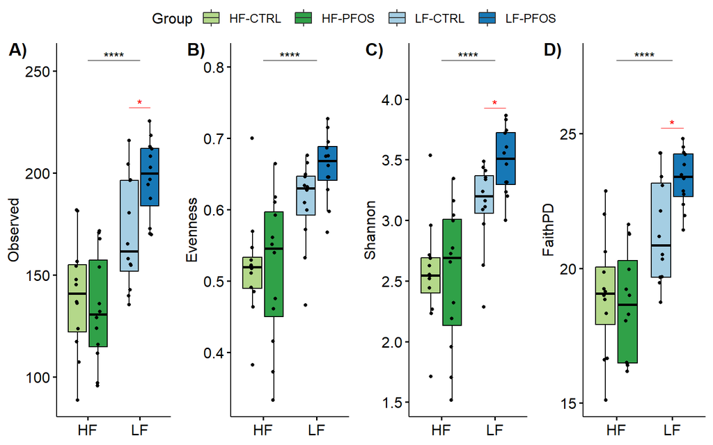

```
##
## $Observed
## $Observed$fit
## Call:
##    aov(formula = as.formula(paste(i, "~", OUTER.VAR, "*", INNER.VAR,
##     sep = " ")), data = adat)
##
## Terms:
##                      feed feed_treat Residuals
## Sum of Squares  26814.380   4649.437 28979.158
## Deg. of Freedom         1          2        44
##
## Residual standard error: 25.66354
## 4 out of 8 effects not estimable
## Estimated effects may be unbalanced
##
## $Observed$ANOVA
## Analysis of Variance Table
##
## Response: Observed
##            Df  Sum Sq Mean Sq F value    Pr(>F)
## feed        1 26814.4 26814.4 40.7131 9.294e-08 ***
## feed_treat  2  4649.4  2324.7  3.5297   0.03787 *
## Residuals  44 28979.2   658.6
## ---
## Signif. codes:  0 '***' 0.001 '**' 0.01 '*' 0.05 '.' 0.1 ' ' 1
##
## $Observed$TukeyHSD
##   Tukey multiple comparisons of means
##     95% family-wise confidence level
##
## Fit: aov(formula = as.formula(paste(i, "~", OUTER.VAR, "*", INNER.VAR, sep = " ")), data = adat)
##
## $feed
##           diff      lwr      upr p adj
## LF-HF 47.27083 32.34013 62.20153 1e-07
##
## $feed_treat
##                      diff        lwr      upr     p adj
## HF_PFOS-HF_CTRL  -5.97500 -33.948905 21.99891 0.9403950
```

[output cut: 131 more lines]

```
##
## Fit: aov(formula = as.formula(paste(i, "~", OUTER.VAR, "*", INNER.VAR, sep = " ")), data = adat)
##
## $feed
##           diff      lwr      upr p adj
## LF-HF 3.505325 2.411451 4.599198 1e-07
##
## $feed_treat
##                       diff        lwr       upr     p adj
## HF_PFOS-HF_CTRL -0.3317139 -2.3811766 1.7177487 0.9726260
## LF_CTRL-HF_CTRL -1.1285600 -3.1780226 0.9209027 0.4637224
## LF_PFOS-HF_CTRL  0.7968461 -1.2526166 2.8463087 0.7281665
## LF_CTRL-HF_PFOS -0.7968461 -2.8463087 1.2526166 0.7281665
## LF_PFOS-HF_PFOS  1.1285600 -0.9209027 3.1780226 0.4637224
## LF_PFOS-LF_CTRL  1.9254060 -0.1240566 3.9748687 0.0724623
```

```r
# Run alpha-diversity analysis and create output data with plot
adiv_output(INNER.VAR, OUTER.VAR, MTRL, DAY)
```

```r
#INNER.VAR = "feed_treat", OUTER.VAR = "feed", MTRL = "Feces", DAY = "d08"

# clear the environment and release memory
rm(list = ls(all.names = TRUE)[ls(all.names = TRUE) != "params"])
invisible(gc())
```

### 5.1.2 Feces day 8

```r
# Load parameters and scripts
params <- readRDS("R_objects/Adiv_params.RDS")
load("scripts/adiv.Rdata")

# Set variables for subset analysis
INNER.VAR <- "feed_treat"
OUTER.VAR <- "feed"
MTRL <- "Feces"
DAY <- "d08"

# Test batch effect for subset
adiv_batch_effect(INNER.VAR, OUTER.VAR, MTRL, DAY)
```

```
## [[1]]
##     feed
##      HF LF
##   c1  7  5
##   c2  7  3
##   c3  5 10
##   c4  5  6
##
## [[2]]
##     feed
##            HF       LF
##   c1 29.16667 20.83333
##   c2 29.16667 12.50000
##   c3 20.83333 41.66667
##   c4 20.83333 25.00000
##
## [[3]]
## # A tibble: 1 × 6
##       n statistic     p    df method          p.signif
## * <int>     <dbl> <dbl> <int> <chr>           <chr>
## 1    48      3.69 0.297     3 Chi-square test ns
```

```
## # A tibble: 2 × 16
##   feed  .y.      group1  group2     n1    n2 statistic     p p.adj p.adj.signif
## * <fct> <chr>    <chr>   <chr>   <int> <int>     <dbl> <dbl> <dbl> <chr>
## 1 HF    Observed HF_CTRL HF_PFOS    12    12        53 0.291 0.582 ns
## 2 LF    Observed LF_CTRL LF_PFOS    12    12        81 0.63  0.63  ns
## # ℹ 6 more variables: y.position <dbl>, groups <named list>, x <dbl>,
## #   xmin <dbl>, xmax <dbl>, p.adj.format <chr>
## # A tibble: 1 × 14
##   .y.      group1 group2    n1    n2 statistic      p  p.adj p.adj.signif
## * <chr>    <chr>  <chr>  <int> <int>     <dbl>  <dbl>  <dbl> <chr>
## 1 Observed HF     LF        24    24       170 0.0144 0.0144 *
## # ℹ 5 more variables: y.position <dbl>, groups <named list>, xmin <dbl>,
## #   xmax <dbl>, p.adj.format <chr>
## # A tibble: 2 × 16
##   feed  .y.      group1  group2     n1    n2 statistic     p p.adj p.adj.signif
## * <fct> <chr>    <chr>   <chr>   <int> <int>     <dbl> <dbl> <dbl> <chr>
## 1 HF    Evenness HF_CTRL HF_PFOS    12    12        52 0.266 0.532 ns
## 2 LF    Evenness LF_CTRL LF_PFOS    12    12        61 0.551 0.551 ns
## # ℹ 6 more variables: y.position <dbl>, groups <named list>, x <dbl>,
## #   xmin <dbl>, xmax <dbl>, p.adj.format <chr>
## # A tibble: 1 × 14
##   .y.    group1 group2    n1    n2 statistic     p p.adj p.adj.signif y.position
## * <chr>  <chr>  <chr>  <int> <int>     <dbl> <dbl> <dbl> <chr>             <dbl>
## 1 Evenn… HF     LF        24    24       216 0.141 0.141 ns                0.744
## # ℹ 4 more variables: groups <named list>, xmin <dbl>, xmax <dbl>,
## #   p.adj.format <chr>
## # A tibble: 2 × 16
##   feed  .y.     group1  group2     n1    n2 statistic     p p.adj p.adj.signif
## * <fct> <chr>   <chr>   <chr>   <int> <int>     <dbl> <dbl> <dbl> <chr>
## 1 HF    Shannon HF_CTRL HF_PFOS    12    12        52 0.266 0.532 ns
## 2 LF    Shannon LF_CTRL LF_PFOS    12    12        66 0.755 0.755 ns
## # ℹ 6 more variables: y.position <dbl>, groups <named list>, x <dbl>,
## #   xmin <dbl>, xmax <dbl>, p.adj.format <chr>
## # A tibble: 1 × 14
##   .y.    group1 group2    n1    n2 statistic     p p.adj p.adj.signif y.position
## * <chr>  <chr>  <chr>  <int> <int>     <dbl> <dbl> <dbl> <chr>             <dbl>
## 1 Shann… HF     LF        24    24       206 0.093 0.093 ns                 3.97
## # ℹ 4 more variables: groups <named list>, xmin <dbl>, xmax <dbl>,
## #   p.adj.format <chr>
## # A tibble: 2 × 16
##   feed  .y.     group1  group2     n1    n2 statistic     p p.adj p.adj.signif
## * <fct> <chr>   <chr>   <chr>   <int> <int>     <dbl> <dbl> <dbl> <chr>
## 1 HF    FaithPD HF_CTRL HF_PFOS    12    12        49 0.198 0.291 ns
## 2 LF    FaithPD LF_CTRL LF_PFOS    12    12        91 0.291 0.291 ns
## # ℹ 6 more variables: y.position <dbl>, groups <named list>, x <dbl>,
## #   xmin <dbl>, xmax <dbl>, p.adj.format <chr>
## # A tibble: 1 × 14
##   .y.     group1 group2    n1    n2 statistic      p  p.adj p.adj.signif
## * <chr>   <chr>  <chr>  <int> <int>     <dbl>  <dbl>  <dbl> <chr>
## 1 FaithPD HF     LF        24    24       185 0.0337 0.0337 *
## # ℹ 5 more variables: y.position <dbl>, groups <named list>, xmin <dbl>,
## #   xmax <dbl>, p.adj.format <chr>
```

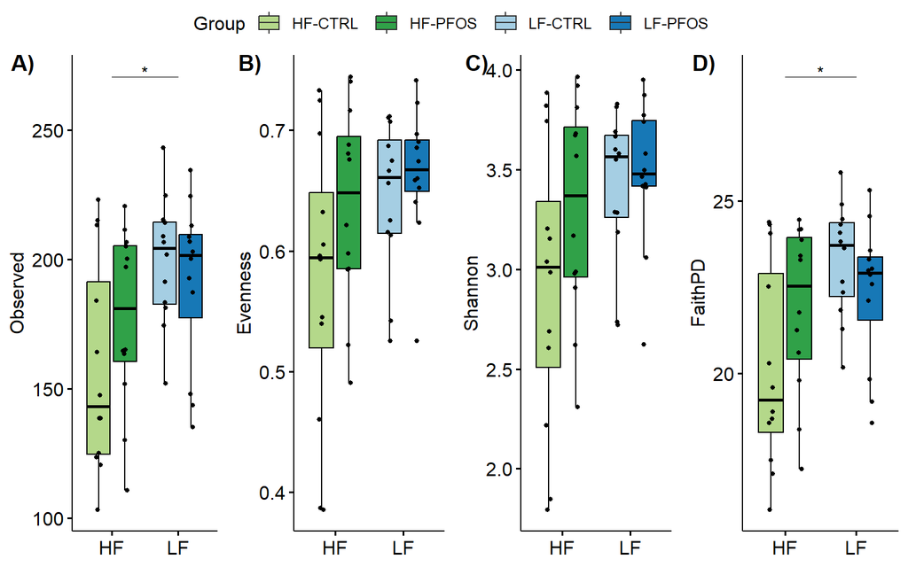

```
##
## $Observed
## $Observed$fit
## Call:
##    aov(formula = as.formula(paste(i, "~", OUTER.VAR, "*", INNER.VAR,
##     sep = " ")), data = adat)
##
## Terms:
##                     feed feed_treat Residuals
## Sum of Squares   9390.09    2619.53  50387.14
## Deg. of Freedom        1          2        44
##
## Residual standard error: 33.84025
## 4 out of 8 effects not estimable
## Estimated effects may be unbalanced
##
## $Observed$ANOVA
## Analysis of Variance Table
##
## Response: Observed
##            Df Sum Sq Mean Sq F value   Pr(>F)
## feed        1   9390  9390.1  8.1998 0.006395 **
## feed_treat  2   2620  1309.8  1.1437 0.327915
## Residuals  44  50387  1145.2
## ---
## Signif. codes:  0 '***' 0.001 '**' 0.01 '*' 0.05 '.' 0.1 ' ' 1
##
## $Observed$TukeyHSD
##   Tukey multiple comparisons of means
##     95% family-wise confidence level
##
## Fit: aov(formula = as.formula(paste(i, "~", OUTER.VAR, "*", INNER.VAR, sep = " ")), data = adat)
##
## $feed
##           diff      lwr      upr     p adj
## LF-HF 27.97333 8.285534 47.66113 0.0063954
##
## $feed_treat
##                       diff       lwr      upr     p adj
## HF_PFOS-HF_CTRL  19.156667 -17.73006 56.04339 0.5142665
```

[output cut: 131 more lines]

```
##
## Fit: aov(formula = as.formula(paste(i, "~", OUTER.VAR, "*", INNER.VAR, sep = " ")), data = adat)
##
## $feed
##          diff       lwr      upr     p adj
## LF-HF 1.79152 0.4318119 3.151228 0.0109888
##
## $feed_treat
##                       diff        lwr      upr     p adj
## HF_PFOS-HF_CTRL  1.7147732 -0.8327528 4.262299 0.2883340
## LF_CTRL-HF_CTRL  1.3357498 -1.2117762 3.883276 0.5061107
## LF_PFOS-HF_CTRL  0.3790234 -2.1685026 2.926549 0.9784943
## LF_CTRL-HF_PFOS -0.3790234 -2.9265494 2.168503 0.9784943
## LF_PFOS-HF_PFOS -1.3357498 -3.8832758 1.211776 0.5061107
## LF_PFOS-LF_CTRL -0.9567264 -3.5042524 1.590800 0.7486149
```

```r
# Run alpha-diversity analysis and create output data with plot
adiv_output(INNER.VAR, OUTER.VAR, MTRL, DAY)
```

```r
# clear the environment and release memory
rm(list = ls(all.names = TRUE)[ls(all.names = TRUE) != "params"])
invisible(gc())
```

### 5.1.3 Feces day 12

```r
# Load parameters and scripts
params <- readRDS("R_objects/Adiv_params.RDS")
load("scripts/adiv.Rdata")

# Set variables for subset analysis
INNER.VAR <- "feed_treat"
OUTER.VAR <- "feed"
MTRL <- "Feces"
DAY <- "d12"

# Test batch effect for subset
adiv_batch_effect(INNER.VAR, OUTER.VAR, MTRL, DAY)
```

```
## [[1]]
##     feed
##      HF LF
##   c1  2  2
##   c2  3  2
##   c3  1  6
##   c4  6  2
##
## [[2]]
##     feed
##             HF        LF
##   c1 16.666667 16.666667
##   c2 25.000000 16.666667
##   c3  8.333333 50.000000
##   c4 50.000000 16.666667
##
## [[3]]
## # A tibble: 1 × 6
##       n statistic     p    df method          p.signif
## * <int>     <dbl> <dbl> <int> <chr>           <chr>
## 1    24      5.77 0.123     3 Chi-square test ns
```

```
## # A tibble: 2 × 16
##   feed  .y.      group1  group2     n1    n2 statistic     p p.adj p.adj.signif
## * <fct> <chr>    <chr>   <chr>   <int> <int>     <dbl> <dbl> <dbl> <chr>
## 1 HF    Observed HF_CTRL HF_PFOS     6     6        17 0.937 0.937 ns
## 2 LF    Observed LF_CTRL LF_PFOS     6     6        19 0.937 0.937 ns
## # ℹ 6 more variables: y.position <dbl>, groups <named list>, x <dbl>,
## #   xmin <dbl>, xmax <dbl>, p.adj.format <chr>
## # A tibble: 1 × 14
##   .y.      group1 group2    n1    n2 statistic        p    p.adj p.adj.signif
## * <chr>    <chr>  <chr>  <int> <int>     <dbl>    <dbl>    <dbl> <chr>
## 1 Observed HF     LF        12    12        15 0.000496 0.000496 ***
## # ℹ 5 more variables: y.position <dbl>, groups <named list>, xmin <dbl>,
## #   xmax <dbl>, p.adj.format <chr>
## # A tibble: 2 × 16
##   feed  .y.      group1  group2     n1    n2 statistic     p p.adj p.adj.signif
## * <fct> <chr>    <chr>   <chr>   <int> <int>     <dbl> <dbl> <dbl> <chr>
## 1 HF    Evenness HF_CTRL HF_PFOS     6     6        19 0.937 0.937 ns
## 2 LF    Evenness LF_CTRL LF_PFOS     6     6        20 0.818 0.937 ns
## # ℹ 6 more variables: y.position <dbl>, groups <named list>, x <dbl>,
## #   xmin <dbl>, xmax <dbl>, p.adj.format <chr>
## # A tibble: 1 × 14
##   .y.    group1 group2    n1    n2 statistic     p p.adj p.adj.signif y.position
## * <chr>  <chr>  <chr>  <int> <int>     <dbl> <dbl> <dbl> <chr>             <dbl>
## 1 Evenn… HF     LF        12    12        28  0.01  0.01 **                0.735
## # ℹ 4 more variables: groups <named list>, xmin <dbl>, xmax <dbl>,
## #   p.adj.format <chr>
## # A tibble: 2 × 16
##   feed  .y.     group1  group2     n1    n2 statistic     p p.adj p.adj.signif
## * <fct> <chr>   <chr>   <chr>   <int> <int>     <dbl> <dbl> <dbl> <chr>
## 1 HF    Shannon HF_CTRL HF_PFOS     6     6        19 0.937 0.937 ns
## 2 LF    Shannon LF_CTRL LF_PFOS     6     6        22 0.589 0.937 ns
## # ℹ 6 more variables: y.position <dbl>, groups <named list>, x <dbl>,
## #   xmin <dbl>, xmax <dbl>, p.adj.format <chr>
## # A tibble: 1 × 14
##   .y.     group1 group2    n1    n2 statistic       p   p.adj p.adj.signif
## * <chr>   <chr>  <chr>  <int> <int>     <dbl>   <dbl>   <dbl> <chr>
## 1 Shannon HF     LF        12    12        25 0.00556 0.00556 **
## # ℹ 5 more variables: y.position <dbl>, groups <named list>, xmin <dbl>,
## #   xmax <dbl>, p.adj.format <chr>
## # A tibble: 2 × 16
##   feed  .y.     group1  group2     n1    n2 statistic     p p.adj p.adj.signif
## * <fct> <chr>   <chr>   <chr>   <int> <int>     <dbl> <dbl> <dbl> <chr>
## 1 HF    FaithPD HF_CTRL HF_PFOS     6     6        17 0.937 0.937 ns
## 2 LF    FaithPD LF_CTRL LF_PFOS     6     6        19 0.937 0.937 ns
## # ℹ 6 more variables: y.position <dbl>, groups <named list>, x <dbl>,
## #   xmin <dbl>, xmax <dbl>, p.adj.format <chr>
## # A tibble: 1 × 14
##   .y.     group1 group2    n1    n2 statistic       p   p.adj p.adj.signif
## * <chr>   <chr>  <chr>  <int> <int>     <dbl>   <dbl>   <dbl> <chr>
## 1 FaithPD HF     LF        12    12        19 0.00143 0.00143 **
## # ℹ 5 more variables: y.position <dbl>, groups <named list>, xmin <dbl>,
## #   xmax <dbl>, p.adj.format <chr>
```

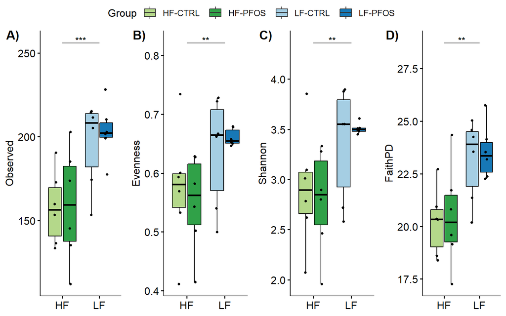

```
##
## $Observed
## $Observed$fit
## Call:
##    aov(formula = as.formula(paste(i, "~", OUTER.VAR, "*", INNER.VAR,
##     sep = " ")), data = adat)
##
## Terms:
##                      feed feed_treat Residuals
## Sum of Squares  10115.131    177.004 12783.037
## Deg. of Freedom         1          2        20
##
## Residual standard error: 25.28145
## 4 out of 8 effects not estimable
## Estimated effects may be unbalanced
##
## $Observed$ANOVA
## Analysis of Variance Table
##
## Response: Observed
##            Df Sum Sq Mean Sq F value    Pr(>F)
## feed        1  10115 10115.1 15.8259 0.0007404 ***
## feed_treat  2    177    88.5  0.1385 0.8715189
## Residuals  20  12783   639.2
## ---
## Signif. codes:  0 '***' 0.001 '**' 0.01 '*' 0.05 '.' 0.1 ' ' 1
##
## $Observed$TukeyHSD
##   Tukey multiple comparisons of means
##     95% family-wise confidence level
##
## Fit: aov(formula = as.formula(paste(i, "~", OUTER.VAR, "*", INNER.VAR, sep = " ")), data = adat)
##
## $feed
##           diff      lwr      upr     p adj
## LF-HF 41.05917 19.52971 62.58862 0.0007404
##
## $feed_treat
##                      diff       lwr      upr     p adj
## HF_PFOS-HF_CTRL  1.321667 -39.53232 42.17565 0.9997245
```

[output cut: 131 more lines]

```
##
## Fit: aov(formula = as.formula(paste(i, "~", OUTER.VAR, "*", INNER.VAR, sep = " ")), data = adat)
##
## $feed
##           diff      lwr      upr     p adj
## LF-HF 3.001952 1.414975 4.588929 0.0007985
##
## $feed_treat
##                        diff       lwr      upr     p adj
## HF_PFOS-HF_CTRL  0.25874196 -2.752683 3.270167 0.9949471
## LF_CTRL-HF_CTRL -0.06034761 -3.071772 2.951077 0.9999344
## LF_PFOS-HF_CTRL  0.31908956 -2.692335 3.330514 0.9906439
## LF_CTRL-HF_PFOS -0.31908956 -3.330514 2.692335 0.9906439
## LF_PFOS-HF_PFOS  0.06034761 -2.951077 3.071772 0.9999344
## LF_PFOS-LF_CTRL  0.37943717 -2.631988 3.390862 0.9845098
```

```r
# Run alpha-diversity analysis and create output data with plot
adiv_output(INNER.VAR, OUTER.VAR, MTRL, DAY)
```

```r
# clear the environment and release memory
rm(list = ls(all.names = TRUE)[ls(all.names = TRUE) != "params"])
invisible(gc())
```

### 5.1.4 Feces day 16

```r
# Load parameters and scripts
params <- readRDS("R_objects/Adiv_params.RDS")
load("scripts/adiv.Rdata")

# Set variables for subset analysis
INNER.VAR <- "feed_treat"
OUTER.VAR <- "feed"
MTRL <- "Feces"
DAY <- "d16"

# Test batch effect for subset
adiv_batch_effect(INNER.VAR, OUTER.VAR, MTRL, DAY)
```

```
## [[1]]
##     feed
##      HF LF
##   c1  2  4
##   c2  3  1
##   c3  4  4
##   c4  3  3
##
## [[2]]
##     feed
##             HF        LF
##   c1 16.666667 33.333333
##   c2 25.000000  8.333333
##   c3 33.333333 33.333333
##   c4 25.000000 25.000000
##
## [[3]]
## # A tibble: 1 × 6
##       n statistic     p    df method          p.signif
## * <int>     <dbl> <dbl> <int> <chr>           <chr>
## 1    24      1.67 0.644     3 Chi-square test ns
```

```
## # A tibble: 2 × 16
##   feed  .y.      group1  group2     n1    n2 statistic     p p.adj p.adj.signif
## * <fct> <chr>    <chr>   <chr>   <int> <int>     <dbl> <dbl> <dbl> <chr>
## 1 HF    Observed HF_CTRL HF_PFOS     6     6        10 0.24  0.48  ns
## 2 LF    Observed LF_CTRL LF_PFOS     6     6        21 0.699 0.699 ns
## # ℹ 6 more variables: y.position <dbl>, groups <named list>, x <dbl>,
## #   xmin <dbl>, xmax <dbl>, p.adj.format <chr>
## # A tibble: 1 × 14
##   .y.      group1 group2    n1    n2 statistic      p  p.adj p.adj.signif
## * <chr>    <chr>  <chr>  <int> <int>     <dbl>  <dbl>  <dbl> <chr>
## 1 Observed HF     LF        12    12        29 0.0121 0.0121 *
## # ℹ 5 more variables: y.position <dbl>, groups <named list>, xmin <dbl>,
## #   xmax <dbl>, p.adj.format <chr>
## # A tibble: 2 × 16
##   feed  .y.      group1  group2     n1    n2 statistic     p p.adj p.adj.signif
## * <fct> <chr>    <chr>   <chr>   <int> <int>     <dbl> <dbl> <dbl> <chr>
## 1 HF    Evenness HF_CTRL HF_PFOS     6     6        10 0.24  0.48  ns
## 2 LF    Evenness LF_CTRL LF_PFOS     6     6        16 0.818 0.818 ns
## # ℹ 6 more variables: y.position <dbl>, groups <named list>, x <dbl>,
## #   xmin <dbl>, xmax <dbl>, p.adj.format <chr>
## # A tibble: 1 × 14
##   .y.    group1 group2    n1    n2 statistic     p p.adj p.adj.signif y.position
## * <chr>  <chr>  <chr>  <int> <int>     <dbl> <dbl> <dbl> <chr>             <dbl>
## 1 Evenn… HF     LF        12    12        41 0.078 0.078 ns                0.708
## # ℹ 4 more variables: groups <named list>, xmin <dbl>, xmax <dbl>,
## #   p.adj.format <chr>
## # A tibble: 2 × 16
##   feed  .y.     group1  group2     n1    n2 statistic     p p.adj p.adj.signif
## * <fct> <chr>   <chr>   <chr>   <int> <int>     <dbl> <dbl> <dbl> <chr>
## 1 HF    Shannon HF_CTRL HF_PFOS     6     6         9 0.18  0.36  ns
## 2 LF    Shannon LF_CTRL LF_PFOS     6     6        19 0.937 0.937 ns
## # ℹ 6 more variables: y.position <dbl>, groups <named list>, x <dbl>,
## #   xmin <dbl>, xmax <dbl>, p.adj.format <chr>
## # A tibble: 1 × 14
##   .y.     group1 group2    n1    n2 statistic      p  p.adj p.adj.signif
## * <chr>   <chr>  <chr>  <int> <int>     <dbl>  <dbl>  <dbl> <chr>
## 1 Shannon HF     LF        12    12        38 0.0519 0.0519 ns
## # ℹ 5 more variables: y.position <dbl>, groups <named list>, xmin <dbl>,
## #   xmax <dbl>, p.adj.format <chr>
## # A tibble: 2 × 16
##   feed  .y.     group1  group2     n1    n2 statistic     p p.adj p.adj.signif
## * <fct> <chr>   <chr>   <chr>   <int> <int>     <dbl> <dbl> <dbl> <chr>
## 1 HF    FaithPD HF_CTRL HF_PFOS     6     6         8 0.132 0.264 ns
## 2 LF    FaithPD LF_CTRL LF_PFOS     6     6        20 0.818 0.818 ns
## # ℹ 6 more variables: y.position <dbl>, groups <named list>, x <dbl>,
## #   xmin <dbl>, xmax <dbl>, p.adj.format <chr>
## # A tibble: 1 × 14
##   .y.     group1 group2    n1    n2 statistic      p  p.adj p.adj.signif
## * <chr>   <chr>  <chr>  <int> <int>     <dbl>  <dbl>  <dbl> <chr>
## 1 FaithPD HF     LF        12    12        32 0.0205 0.0205 *
## # ℹ 5 more variables: y.position <dbl>, groups <named list>, xmin <dbl>,
## #   xmax <dbl>, p.adj.format <chr>
```

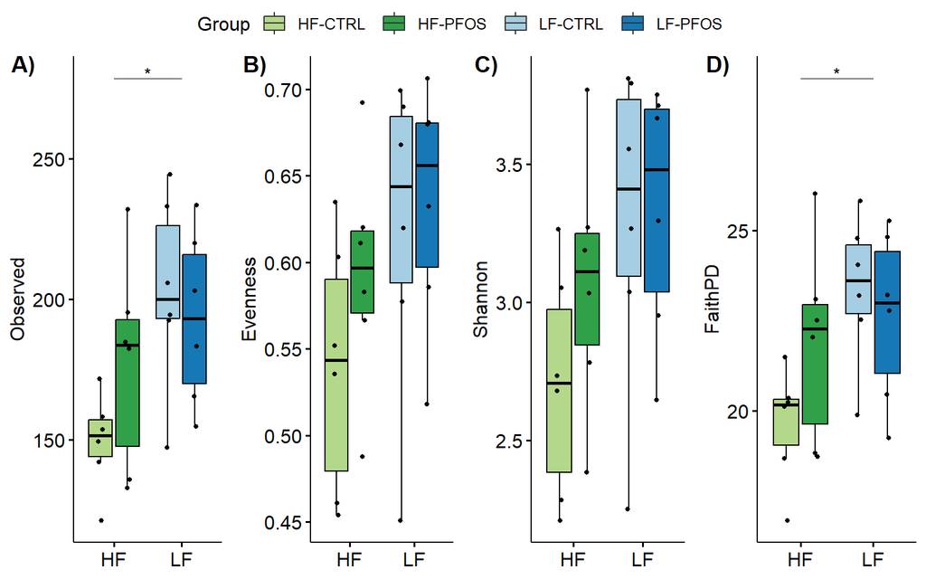

```
##
## $Observed
## $Observed$fit
## Call:
##    aov(formula = as.formula(paste(i, "~", OUTER.VAR, "*", INNER.VAR,
##     sep = " ")), data = adat)
##
## Terms:
##                      feed feed_treat Residuals
## Sum of Squares   7282.605   2599.397 19228.597
## Deg. of Freedom         1          2        20
##
## Residual standard error: 31.00693
## 4 out of 8 effects not estimable
## Estimated effects may be unbalanced
##
## $Observed$ANOVA
## Analysis of Variance Table
##
## Response: Observed
##            Df  Sum Sq Mean Sq F value  Pr(>F)
## feed        1  7282.6  7282.6  7.5748 0.01229 *
## feed_treat  2  2599.4  1299.7  1.3518 0.28141
## Residuals  20 19228.6   961.4
## ---
## Signif. codes:  0 '***' 0.001 '**' 0.01 '*' 0.05 '.' 0.1 ' ' 1
##
## $Observed$TukeyHSD
##   Tukey multiple comparisons of means
##     95% family-wise confidence level
##
## Fit: aov(formula = as.formula(paste(i, "~", OUTER.VAR, "*", INNER.VAR, sep = " ")), data = adat)
##
## $feed
##           diff      lwr      upr     p adj
## LF-HF 34.83917 8.433943 61.24439 0.0122859
##
## $feed_treat
##                       diff       lwr      upr     p adj
## HF_PFOS-HF_CTRL  27.856667 -22.24950 77.96283 0.4247689
```

[output cut: 131 more lines]

```
##
## Fit: aov(formula = as.formula(paste(i, "~", OUTER.VAR, "*", INNER.VAR, sep = " ")), data = adat)
##
## $feed
##           diff       lwr      upr     p adj
## LF-HF 2.243192 0.3338714 4.152512 0.0235811
##
## $feed_treat
##                       diff       lwr      upr     p adj
## HF_PFOS-HF_CTRL  2.2289229 -1.394175 5.852021 0.3389809
## LF_CTRL-HF_CTRL  1.4872598 -2.135838 5.110358 0.6645568
## LF_PFOS-HF_CTRL  0.7416631 -2.881435 4.364761 0.9390025
## LF_CTRL-HF_PFOS -0.7416631 -4.364761 2.881435 0.9390025
## LF_PFOS-HF_PFOS -1.4872598 -5.110358 2.135838 0.6645568
## LF_PFOS-LF_CTRL -0.7455966 -4.368695 2.877501 0.9381160
```

```r
# Run alpha-diversity analysis and create output data with plot
adiv_output(INNER.VAR, OUTER.VAR, MTRL, DAY)
```

```r
# clear the environment and release memory
rm(list = ls(all.names = TRUE)[ls(all.names = TRUE) != "params"])
invisible(gc())
```

### 5.1.5 Feces day 20 (not included in presented data)

```r
# Load parameters and scripts
params <- readRDS("R_objects/Adiv_params.RDS")
load("scripts/adiv.Rdata")

# Set variables for subset analysis
INNER.VAR <- "feed_treat"
OUTER.VAR <- "feed"
MTRL <- "Feces"
DAY <- "d20"

# Test batch effect for subset
adiv_batch_effect(INNER.VAR, OUTER.VAR, MTRL, DAY)
```

```
## [[1]]
##     feed
##      HF LF
##   c1  4  1
##   c2  4  4
##   c3  0  2
##   c4  4  5
##
## [[2]]
##     feed
##             HF        LF
##   c1 33.333333  8.333333
##   c2 33.333333 33.333333
##   c3  0.000000 16.666667
##   c4 33.333333 41.666667
##
## [[3]]
## # A tibble: 1 × 6
##       n statistic     p    df method          p.signif
## * <int>     <dbl> <dbl> <int> <chr>           <chr>
## 1    24      3.91 0.271     3 Chi-square test ns
```

```
## # A tibble: 2 × 16
##   feed  .y.      group1  group2     n1    n2 statistic     p p.adj p.adj.signif
## * <fct> <chr>    <chr>   <chr>   <int> <int>     <dbl> <dbl> <dbl> <chr>
## 1 HF    Observed HF_CTRL HF_PFOS     6     6        12 0.394 0.394 ns
## 2 LF    Observed LF_CTRL LF_PFOS     6     6         9 0.18  0.36  ns
## # ℹ 6 more variables: y.position <dbl>, groups <named list>, x <dbl>,
## #   xmin <dbl>, xmax <dbl>, p.adj.format <chr>
## # A tibble: 1 × 14
##   .y.      group1 group2    n1    n2 statistic       p   p.adj p.adj.signif
## * <chr>    <chr>  <chr>  <int> <int>     <dbl>   <dbl>   <dbl> <chr>
## 1 Observed HF     LF        12    12        23 0.00364 0.00364 **
## # ℹ 5 more variables: y.position <dbl>, groups <named list>, xmin <dbl>,
## #   xmax <dbl>, p.adj.format <chr>
## # A tibble: 2 × 16
##   feed  .y.      group1  group2     n1    n2 statistic     p p.adj p.adj.signif
## * <fct> <chr>    <chr>   <chr>   <int> <int>     <dbl> <dbl> <dbl> <chr>
## 1 HF    Evenness HF_CTRL HF_PFOS     6     6        18  1     1    ns
## 2 LF    Evenness LF_CTRL LF_PFOS     6     6         9  0.18  0.36 ns
## # ℹ 6 more variables: y.position <dbl>, groups <named list>, x <dbl>,
## #   xmin <dbl>, xmax <dbl>, p.adj.format <chr>
## # A tibble: 1 × 14
##   .y.      group1 group2    n1    n2 statistic      p  p.adj p.adj.signif
## * <chr>    <chr>  <chr>  <int> <int>     <dbl>  <dbl>  <dbl> <chr>
## 1 Evenness HF     LF        12    12        39 0.0597 0.0597 ns
## # ℹ 5 more variables: y.position <dbl>, groups <named list>, xmin <dbl>,
## #   xmax <dbl>, p.adj.format <chr>
## # A tibble: 2 × 16
##   feed  .y.     group1  group2     n1    n2 statistic     p p.adj p.adj.signif
## * <fct> <chr>   <chr>   <chr>   <int> <int>     <dbl> <dbl> <dbl> <chr>
## 1 HF    Shannon HF_CTRL HF_PFOS     6     6        18 1     1     ns
## 2 LF    Shannon LF_CTRL LF_PFOS     6     6         8 0.132 0.264 ns
## # ℹ 6 more variables: y.position <dbl>, groups <named list>, x <dbl>,
## #   xmin <dbl>, xmax <dbl>, p.adj.format <chr>
## # A tibble: 1 × 14
##   .y.     group1 group2    n1    n2 statistic      p  p.adj p.adj.signif
## * <chr>   <chr>  <chr>  <int> <int>     <dbl>  <dbl>  <dbl> <chr>
## 1 Shannon HF     LF        12    12        33 0.0242 0.0242 *
## # ℹ 5 more variables: y.position <dbl>, groups <named list>, xmin <dbl>,
## #   xmax <dbl>, p.adj.format <chr>
## # A tibble: 2 × 16
##   feed  .y.     group1  group2     n1    n2 statistic     p p.adj p.adj.signif
## * <fct> <chr>   <chr>   <chr>   <int> <int>     <dbl> <dbl> <dbl> <chr>
## 1 HF    FaithPD HF_CTRL HF_PFOS     6     6        13 0.485 0.485 ns
## 2 LF    FaithPD LF_CTRL LF_PFOS     6     6         9 0.18  0.36  ns
## # ℹ 6 more variables: y.position <dbl>, groups <named list>, x <dbl>,
## #   xmin <dbl>, xmax <dbl>, p.adj.format <chr>
## # A tibble: 1 × 14
##   .y.     group1 group2    n1    n2 statistic      p  p.adj p.adj.signif
## * <chr>   <chr>  <chr>  <int> <int>     <dbl>  <dbl>  <dbl> <chr>
## 1 FaithPD HF     LF        12    12        31 0.0173 0.0173 *
## # ℹ 5 more variables: y.position <dbl>, groups <named list>, xmin <dbl>,
## #   xmax <dbl>, p.adj.format <chr>
```

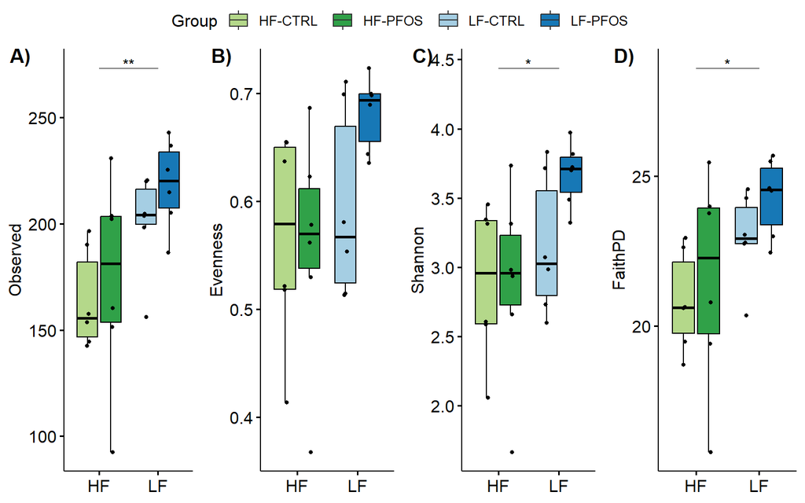

```
##
## $Observed
## $Observed$fit
## Call:
##    aov(formula = as.formula(paste(i, "~", OUTER.VAR, "*", INNER.VAR,
##     sep = " ")), data = adat)
##
## Terms:
##                      feed feed_treat Residuals
## Sum of Squares   9937.312   1232.483 19969.801
## Deg. of Freedom         1          2        20
##
## Residual standard error: 31.59889
## 4 out of 8 effects not estimable
## Estimated effects may be unbalanced
##
## $Observed$ANOVA
## Analysis of Variance Table
##
## Response: Observed
##            Df  Sum Sq Mean Sq F value   Pr(>F)
## feed        1  9937.3  9937.3  9.9523 0.004985 **
## feed_treat  2  1232.5   616.2  0.6172 0.549428
## Residuals  20 19969.8   998.5
## ---
## Signif. codes:  0 '***' 0.001 '**' 0.01 '*' 0.05 '.' 0.1 ' ' 1
##
## $Observed$TukeyHSD
##   Tukey multiple comparisons of means
##     95% family-wise confidence level
##
## Fit: aov(formula = as.formula(paste(i, "~", OUTER.VAR, "*", INNER.VAR, sep = " ")), data = adat)
##
## $feed
##           diff      lwr    upr     p adj
## LF-HF 40.69667 13.78733 67.606 0.0049849
##
## $feed_treat
##                       diff       lwr      upr     p adj
## HF_PFOS-HF_CTRL   9.356667 -41.70609 60.41942 0.9550515
```

[output cut: 131 more lines]

```
##
## Fit: aov(formula = as.formula(paste(i, "~", OUTER.VAR, "*", INNER.VAR, sep = " ")), data = adat)
##
## $feed
##           diff       lwr      upr     p adj
## LF-HF 2.445074 0.5551268 4.335022 0.0138183
##
## $feed_treat
##                       diff       lwr      upr     p adj
## HF_PFOS-HF_CTRL  0.6992288 -2.887108 4.285565 0.9466291
## LF_CTRL-HF_CTRL -0.3156976 -3.902034 3.270639 0.9945727
## LF_PFOS-HF_CTRL  1.0149264 -2.571410 4.601263 0.8571769
## LF_CTRL-HF_PFOS -1.0149264 -4.601263 2.571410 0.8571769
## LF_PFOS-HF_PFOS  0.3156976 -3.270639 3.902034 0.9945727
## LF_PFOS-LF_CTRL  1.3306240 -2.255712 4.916960 0.7293474
```

```r
# Run alpha-diversity analysis and create output data with plot
adiv_output(INNER.VAR, OUTER.VAR, MTRL, DAY)
```

```r
# clear the environment and release memory
rm(list = ls(all.names = TRUE)[ls(all.names = TRUE) != "params"])
invisible(gc())
```

### 5.1.6 Feces day 21

```r
# Load parameters and scripts
params <- readRDS("R_objects/Adiv_params.RDS")
load("scripts/adiv.Rdata")

# Set variables for subset analysis
INNER.VAR <- "feed_treat"
OUTER.VAR <- "feed"
MTRL <- "Feces"
DAY <- "d21"

# Test batch effect for subset
adiv_batch_effect(INNER.VAR, OUTER.VAR, MTRL, DAY)
```

```
## [[1]]
##     feed
##      HF LF
##   c1  3  2
##   c2  1  4
##   c3  4  3
##   c4  4  3
##
## [[2]]
##     feed
##             HF        LF
##   c1 25.000000 16.666667
##   c2  8.333333 33.333333
##   c3 33.333333 25.000000
##   c4 33.333333 25.000000
##
## [[3]]
## # A tibble: 1 × 6
##       n statistic     p    df method          p.signif
## * <int>     <dbl> <dbl> <int> <chr>           <chr>
## 1    24      2.29 0.515     3 Chi-square test ns
```

```
## # A tibble: 2 × 16
##   feed  .y.      group1  group2     n1    n2 statistic     p p.adj p.adj.signif
## * <fct> <chr>    <chr>   <chr>   <int> <int>     <dbl> <dbl> <dbl> <chr>
## 1 HF    Observed HF_CTRL HF_PFOS     6     6        22 0.589 0.937 ns
## 2 LF    Observed LF_CTRL LF_PFOS     6     6        19 0.937 0.937 ns
## # ℹ 6 more variables: y.position <dbl>, groups <named list>, x <dbl>,
## #   xmin <dbl>, xmax <dbl>, p.adj.format <chr>
## # A tibble: 1 × 14
##   .y.    group1 group2    n1    n2 statistic     p p.adj p.adj.signif y.position
## * <chr>  <chr>  <chr>  <int> <int>     <dbl> <dbl> <dbl> <chr>             <dbl>
## 1 Obser… HF     LF        12    12        46 0.143 0.143 ns                 237.
## # ℹ 4 more variables: groups <named list>, xmin <dbl>, xmax <dbl>,
## #   p.adj.format <chr>
## # A tibble: 2 × 16
##   feed  .y.      group1  group2     n1    n2 statistic     p p.adj p.adj.signif
## * <fct> <chr>    <chr>   <chr>   <int> <int>     <dbl> <dbl> <dbl> <chr>
## 1 HF    Evenness HF_CTRL HF_PFOS     6     6        22 0.589 0.589 ns
## 2 LF    Evenness LF_CTRL LF_PFOS     6     6        10 0.24  0.48  ns
## # ℹ 6 more variables: y.position <dbl>, groups <named list>, x <dbl>,
## #   xmin <dbl>, xmax <dbl>, p.adj.format <chr>
## # A tibble: 1 × 14
##   .y.    group1 group2    n1    n2 statistic     p p.adj p.adj.signif y.position
## * <chr>  <chr>  <chr>  <int> <int>     <dbl> <dbl> <dbl> <chr>             <dbl>
## 1 Evenn… HF     LF        12    12        46 0.143 0.143 ns                0.731
## # ℹ 4 more variables: groups <named list>, xmin <dbl>, xmax <dbl>,
## #   p.adj.format <chr>
## # A tibble: 2 × 16
##   feed  .y.     group1  group2     n1    n2 statistic     p p.adj p.adj.signif
## * <fct> <chr>   <chr>   <chr>   <int> <int>     <dbl> <dbl> <dbl> <chr>
## 1 HF    Shannon HF_CTRL HF_PFOS     6     6        21 0.699 0.699 ns
## 2 LF    Shannon LF_CTRL LF_PFOS     6     6        11 0.31  0.62  ns
## # ℹ 6 more variables: y.position <dbl>, groups <named list>, x <dbl>,
## #   xmin <dbl>, xmax <dbl>, p.adj.format <chr>
## # A tibble: 1 × 14
##   .y.    group1 group2    n1    n2 statistic     p p.adj p.adj.signif y.position
## * <chr>  <chr>  <chr>  <int> <int>     <dbl> <dbl> <dbl> <chr>             <dbl>
## 1 Shann… HF     LF        12    12        47  0.16  0.16 ns                 3.97
## # ℹ 4 more variables: groups <named list>, xmin <dbl>, xmax <dbl>,
## #   p.adj.format <chr>
## # A tibble: 2 × 16
##   feed  .y.     group1  group2     n1    n2 statistic     p p.adj p.adj.signif
## * <fct> <chr>   <chr>   <chr>   <int> <int>     <dbl> <dbl> <dbl> <chr>
## 1 HF    FaithPD HF_CTRL HF_PFOS     6     6        22 0.589 0.589 ns
## 2 LF    FaithPD LF_CTRL LF_PFOS     6     6        22 0.589 0.589 ns
## # ℹ 6 more variables: y.position <dbl>, groups <named list>, x <dbl>,
## #   xmin <dbl>, xmax <dbl>, p.adj.format <chr>
## # A tibble: 1 × 14
##   .y.    group1 group2    n1    n2 statistic     p p.adj p.adj.signif y.position
## * <chr>  <chr>  <chr>  <int> <int>     <dbl> <dbl> <dbl> <chr>             <dbl>
## 1 Faith… HF     LF        12    12        48 0.178 0.178 ns                 26.1
## # ℹ 4 more variables: groups <named list>, xmin <dbl>, xmax <dbl>,
## #   p.adj.format <chr>
```

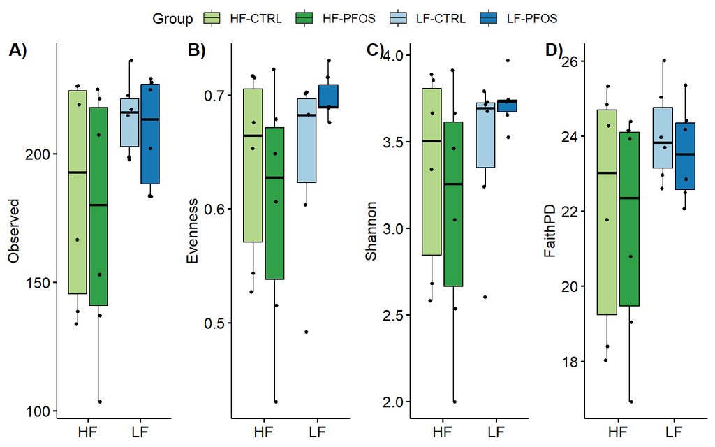

```
##
## $Observed
## $Observed$fit
## Call:
##    aov(formula = as.formula(paste(i, "~", OUTER.VAR, "*", INNER.VAR,
##     sep = " ")), data = adat)
##
## Terms:
##                      feed feed_treat Residuals
## Sum of Squares   6035.365    446.398 25901.234
## Deg. of Freedom         1          2        20
##
## Residual standard error: 35.98697
## 4 out of 8 effects not estimable
## Estimated effects may be unbalanced
##
## $Observed$ANOVA
## Analysis of Variance Table
##
## Response: Observed
##            Df  Sum Sq Mean Sq F value Pr(>F)
## feed        1  6035.4  6035.4  4.6603 0.0432 *
## feed_treat  2   446.4   223.2  0.1723 0.8429
## Residuals  20 25901.2  1295.1
## ---
## Signif. codes:  0 '***' 0.001 '**' 0.01 '*' 0.05 '.' 0.1 ' ' 1
##
## $Observed$TukeyHSD
##   Tukey multiple comparisons of means
##     95% family-wise confidence level
##
## Fit: aov(formula = as.formula(paste(i, "~", OUTER.VAR, "*", INNER.VAR, sep = " ")), data = adat)
##
## $feed
##           diff      lwr      upr    p adj
## LF-HF 31.71583 1.069658 62.36201 0.043197
##
## $feed_treat
##                       diff       lwr      upr     p adj
## HF_PFOS-HF_CTRL -10.561667 -68.71540 47.59207 0.9561503
```

[output cut: 129 more lines]

```
##
## Fit: aov(formula = as.formula(paste(i, "~", OUTER.VAR, "*", INNER.VAR, sep = " ")), data = adat)
##
## $feed
##           diff         lwr     upr     p adj
## LF-HF 1.979145 -0.09121978 4.04951 0.0599596
##
## $feed_treat
##                        diff       lwr      upr     p adj
## HF_PFOS-HF_CTRL -0.56627348 -4.494968 3.362421 0.9771841
## LF_CTRL-HF_CTRL -0.04040205 -3.969096 3.888292 0.9999911
## LF_PFOS-HF_CTRL -0.52587143 -4.454566 3.402823 0.9815539
## LF_CTRL-HF_PFOS  0.52587143 -3.402823 4.454566 0.9815539
## LF_PFOS-HF_PFOS  0.04040205 -3.888292 3.969096 0.9999911
## LF_PFOS-LF_CTRL -0.48546938 -4.414164 3.443225 0.9853591
```

```r
# Run alpha-diversity analysis and create output data with plot
adiv_output(INNER.VAR, OUTER.VAR, MTRL, DAY)
```

```r
# clear the environment and release memory
rm(list = ls(all.names = TRUE)[ls(all.names = TRUE) != "params"])
invisible(gc())
```

### 5.1.7 Ileum day 8

```r
# Load parameters and scripts
params <- readRDS("R_objects/Adiv_params.RDS")
load("scripts/adiv.Rdata")

# Set variables for subset analysis
INNER.VAR <- "feed_treat"
OUTER.VAR <- "feed"
MTRL <- "Ileum"
DAY <- "d08"

# Test batch effect for subset
adiv_batch_effect(INNER.VAR, OUTER.VAR, MTRL, DAY)
```

```
## [[1]]
##     feed
##      HF LF
##   c1  3  1
##   c2  3  2
##   c3  3  3
##   c4  3  4
##
## [[2]]
##     feed
##      HF LF
##   c1 25 10
##   c2 25 20
##   c3 25 30
##   c4 25 40
##
## [[3]]
## # A tibble: 1 × 6
##       n statistic     p    df method          p.signif
## * <int>     <dbl> <dbl> <int> <chr>           <chr>
## 1    22      1.17  0.76     3 Chi-square test ns
```

```
## # A tibble: 2 × 16
##   feed  .y.      group1  group2     n1    n2 statistic     p p.adj p.adj.signif
## * <fct> <chr>    <chr>   <chr>   <int> <int>     <dbl> <dbl> <dbl> <chr>
## 1 HF    Observed HF_CTRL HF_PFOS     6     6        17 0.937 0.937 ns
## 2 LF    Observed LF_CTRL LF_PFOS     5     5        23 0.032 0.064 ns
## # ℹ 6 more variables: y.position <dbl>, groups <named list>, x <dbl>,
## #   xmin <dbl>, xmax <dbl>, p.adj.format <chr>
## # A tibble: 1 × 14
##   .y.    group1 group2    n1    n2 statistic     p p.adj p.adj.signif y.position
## * <chr>  <chr>  <chr>  <int> <int>     <dbl> <dbl> <dbl> <chr>             <dbl>
## 1 Obser… HF     LF        12    10        52 0.628 0.628 ns                 94.0
## # ℹ 4 more variables: groups <named list>, xmin <dbl>, xmax <dbl>,
## #   p.adj.format <chr>
## # A tibble: 2 × 16
##   feed  .y.      group1  group2     n1    n2 statistic     p p.adj p.adj.signif
## * <fct> <chr>    <chr>   <chr>   <int> <int>     <dbl> <dbl> <dbl> <chr>
## 1 HF    Evenness HF_CTRL HF_PFOS     6     6        12 0.394 0.394 ns
## 2 LF    Evenness LF_CTRL LF_PFOS     5     5        23 0.032 0.064 ns
## # ℹ 6 more variables: y.position <dbl>, groups <named list>, x <dbl>,
## #   xmin <dbl>, xmax <dbl>, p.adj.format <chr>
## # A tibble: 1 × 14
##   .y.    group1 group2    n1    n2 statistic     p p.adj p.adj.signif y.position
## * <chr>  <chr>  <chr>  <int> <int>     <dbl> <dbl> <dbl> <chr>             <dbl>
## 1 Evenn… HF     LF        12    10        35 0.107 0.107 ns                0.409
## # ℹ 4 more variables: groups <named list>, xmin <dbl>, xmax <dbl>,
## #   p.adj.format <chr>
## # A tibble: 2 × 16
##   feed  .y.     group1  group2     n1    n2 statistic     p p.adj p.adj.signif
## * <fct> <chr>   <chr>   <chr>   <int> <int>     <dbl> <dbl> <dbl> <chr>
## 1 HF    Shannon HF_CTRL HF_PFOS     6     6        11 0.31  0.31  ns
## 2 LF    Shannon LF_CTRL LF_PFOS     5     5        24 0.016 0.032 *
## # ℹ 6 more variables: y.position <dbl>, groups <named list>, x <dbl>,
## #   xmin <dbl>, xmax <dbl>, p.adj.format <chr>
## # A tibble: 1 × 14
##   .y.     group1 group2    n1    n2 statistic      p  p.adj p.adj.signif
## * <chr>   <chr>  <chr>  <int> <int>     <dbl>  <dbl>  <dbl> <chr>
## 1 Shannon HF     LF        12    10        30 0.0503 0.0503 ns
## # ℹ 5 more variables: y.position <dbl>, groups <named list>, xmin <dbl>,
## #   xmax <dbl>, p.adj.format <chr>
## # A tibble: 2 × 16
##   feed  .y.     group1  group2     n1    n2 statistic     p p.adj p.adj.signif
## * <fct> <chr>   <chr>   <chr>   <int> <int>     <dbl> <dbl> <dbl> <chr>
## 1 HF    FaithPD HF_CTRL HF_PFOS     6     6        19 0.937 0.937 ns
## 2 LF    FaithPD LF_CTRL LF_PFOS     5     5        22 0.056 0.112 ns
## # ℹ 6 more variables: y.position <dbl>, groups <named list>, x <dbl>,
## #   xmin <dbl>, xmax <dbl>, p.adj.format <chr>
## # A tibble: 1 × 14
##   .y.    group1 group2    n1    n2 statistic     p p.adj p.adj.signif y.position
## * <chr>  <chr>  <chr>  <int> <int>     <dbl> <dbl> <dbl> <chr>             <dbl>
## 1 Faith… HF     LF        12    10        64 0.821 0.821 ns                 15.1
## # ℹ 4 more variables: groups <named list>, xmin <dbl>, xmax <dbl>,
## #   p.adj.format <chr>
```

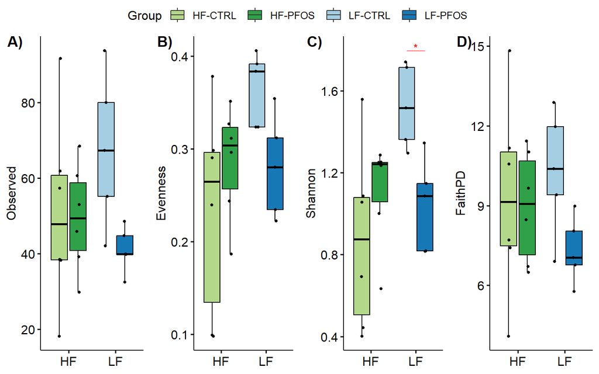

```
##
## $Observed
## $Observed$fit
## Call:
##    aov(formula = as.formula(paste(i, "~", OUTER.VAR, "*", INNER.VAR,
##     sep = " ")), data = adat)
##
## Terms:
##                     feed feed_treat Residuals
## Sum of Squares    94.387   1771.941  6011.242
## Deg. of Freedom        1          2        18
##
## Residual standard error: 18.27451
## 4 out of 8 effects not estimable
## Estimated effects may be unbalanced
##
## $Observed$ANOVA
## Analysis of Variance Table
##
## Response: Observed
##            Df Sum Sq Mean Sq F value  Pr(>F)
## feed        1   94.4   94.39  0.2826 0.60148
## feed_treat  2 1771.9  885.97  2.6529 0.09778 .
## Residuals  18 6011.2  333.96
## ---
## Signif. codes:  0 '***' 0.001 '**' 0.01 '*' 0.05 '.' 0.1 ' ' 1
##
## $Observed$TukeyHSD
##   Tukey multiple comparisons of means
##     95% family-wise confidence level
##
## Fit: aov(formula = as.formula(paste(i, "~", OUTER.VAR, "*", INNER.VAR, sep = " ")), data = adat)
##
## $feed
##           diff       lwr      upr     p adj
## LF-HF 4.159833 -12.27921 20.59887 0.6014825
##
## $feed_treat
##                       diff       lwr       upr     p adj
## HF_PFOS-HF_CTRL  -1.471667 -31.29128 28.347942 0.9989939
```

[output cut: 129 more lines]

```
##
## Fit: aov(formula = as.formula(paste(i, "~", OUTER.VAR, "*", INNER.VAR, sep = " ")), data = adat)
##
## $feed
##             diff       lwr      upr     p adj
## LF-HF -0.3139887 -2.624087 1.996109 0.7784771
##
## $feed_treat
##                       diff       lwr      upr     p adj
## HF_PFOS-HF_CTRL -0.3327039 -4.523108 3.857700 0.9958669
## LF_CTRL-HF_CTRL  1.3264266 -3.068506 5.721359 0.8284889
## LF_PFOS-HF_CTRL -1.6591305 -6.054063 2.735802 0.7132834
## LF_CTRL-HF_PFOS  1.6591305 -2.735802 6.054063 0.7132834
## LF_PFOS-HF_PFOS -1.3264266 -5.721359 3.068506 0.8284889
## LF_PFOS-LF_CTRL -2.9855571 -7.575914 1.604800 0.2886411
```

```r
# Run alpha-diversity analysis and create output data with plot
adiv_output(INNER.VAR, OUTER.VAR, MTRL, DAY)
```

```r
# clear the environment and release memory
rm(list = ls(all.names = TRUE)[ls(all.names = TRUE) != "params"])
invisible(gc())
```

### 5.1.8 Ileum day 21

```r
# Load parameters and scripts
params <- readRDS("R_objects/Adiv_params.RDS")
load("scripts/adiv.Rdata")

# Set variables for subset analysis
INNER.VAR <- "feed_treat"
OUTER.VAR <- "feed"
MTRL <- "Ileum"
DAY <- "d21"

# Test batch effect for subset
adiv_batch_effect(INNER.VAR, OUTER.VAR, MTRL, DAY)
```

```
## [[1]]
##     feed
##      HF LF
##   c1  2  4
##   c2  4  2
##   c3  3  3
##   c4  3  2
##
## [[2]]
##     feed
##            HF       LF
##   c1 16.66667 36.36364
##   c2 33.33333 18.18182
##   c3 25.00000 27.27273
##   c4 25.00000 18.18182
##
## [[3]]
## # A tibble: 1 × 6
##       n statistic     p    df method          p.signif
## * <int>     <dbl> <dbl> <int> <chr>           <chr>
## 1    23      1.49 0.684     3 Chi-square test ns
```

```
## # A tibble: 2 × 16
##   feed  .y.      group1  group2     n1    n2 statistic     p p.adj p.adj.signif
## * <fct> <chr>    <chr>   <chr>   <int> <int>     <dbl> <dbl> <dbl> <chr>
## 1 HF    Observed HF_CTRL HF_PFOS     6     6        20 0.818     1 ns
## 2 LF    Observed LF_CTRL LF_PFOS     5     6        15 1         1 ns
## # ℹ 6 more variables: y.position <dbl>, groups <named list>, x <dbl>,
## #   xmin <dbl>, xmax <dbl>, p.adj.format <chr>
## # A tibble: 1 × 14
##   .y.    group1 group2    n1    n2 statistic     p p.adj p.adj.signif y.position
## * <chr>  <chr>  <chr>  <int> <int>     <dbl> <dbl> <dbl> <chr>             <dbl>
## 1 Obser… HF     LF        12    11        84 0.288 0.288 ns                 159.
## # ℹ 4 more variables: groups <named list>, xmin <dbl>, xmax <dbl>,
## #   p.adj.format <chr>
## # A tibble: 2 × 16
##   feed  .y.      group1  group2     n1    n2 statistic     p p.adj p.adj.signif
## * <fct> <chr>    <chr>   <chr>   <int> <int>     <dbl> <dbl> <dbl> <chr>
## 1 HF    Evenness HF_CTRL HF_PFOS     6     6        23 0.485 0.662 ns
## 2 LF    Evenness LF_CTRL LF_PFOS     5     6        18 0.662 0.662 ns
## # ℹ 6 more variables: y.position <dbl>, groups <named list>, x <dbl>,
## #   xmin <dbl>, xmax <dbl>, p.adj.format <chr>
## # A tibble: 1 × 14
##   .y.    group1 group2    n1    n2 statistic     p p.adj p.adj.signif y.position
## * <chr>  <chr>  <chr>  <int> <int>     <dbl> <dbl> <dbl> <chr>             <dbl>
## 1 Evenn… HF     LF        12    11        73 0.695 0.695 ns                0.443
## # ℹ 4 more variables: groups <named list>, xmin <dbl>, xmax <dbl>,
## #   p.adj.format <chr>
## # A tibble: 2 × 16
##   feed  .y.     group1  group2     n1    n2 statistic     p p.adj p.adj.signif
## * <fct> <chr>   <chr>   <chr>   <int> <int>     <dbl> <dbl> <dbl> <chr>
## 1 HF    Shannon HF_CTRL HF_PFOS     6     6        23 0.485 0.537 ns
## 2 LF    Shannon LF_CTRL LF_PFOS     5     6        19 0.537 0.537 ns
## # ℹ 6 more variables: y.position <dbl>, groups <named list>, x <dbl>,
## #   xmin <dbl>, xmax <dbl>, p.adj.format <chr>
## # A tibble: 1 × 14
##   .y.    group1 group2    n1    n2 statistic     p p.adj p.adj.signif y.position
## * <chr>  <chr>  <chr>  <int> <int>     <dbl> <dbl> <dbl> <chr>             <dbl>
## 1 Shann… HF     LF        12    11        71 0.786 0.786 ns                 2.27
## # ℹ 4 more variables: groups <named list>, xmin <dbl>, xmax <dbl>,
## #   p.adj.format <chr>
## # A tibble: 2 × 16
##   feed  .y.     group1  group2     n1    n2 statistic     p p.adj p.adj.signif
## * <fct> <chr>   <chr>   <chr>   <int> <int>     <dbl> <dbl> <dbl> <chr>
## 1 HF    FaithPD HF_CTRL HF_PFOS     6     6        18 1     1     ns
## 2 LF    FaithPD LF_CTRL LF_PFOS     5     6        20 0.429 0.858 ns
## # ℹ 6 more variables: y.position <dbl>, groups <named list>, x <dbl>,
## #   xmin <dbl>, xmax <dbl>, p.adj.format <chr>
## # A tibble: 1 × 14
##   .y.    group1 group2    n1    n2 statistic     p p.adj p.adj.signif y.position
## * <chr>  <chr>  <chr>  <int> <int>     <dbl> <dbl> <dbl> <chr>             <dbl>
## 1 Faith… HF     LF        12    11        83 0.316 0.316 ns                 20.1
## # ℹ 4 more variables: groups <named list>, xmin <dbl>, xmax <dbl>,
## #   p.adj.format <chr>
```

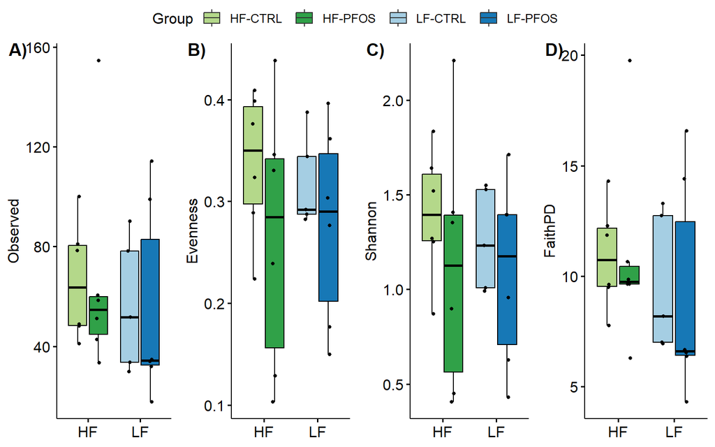

```
##
## $Observed
## $Observed$fit
## Call:
##    aov(formula = as.formula(paste(i, "~", OUTER.VAR, "*", INNER.VAR,
##     sep = " ")), data = adat)
##
## Terms:
##                      feed feed_treat Residuals
## Sum of Squares    647.054      6.349 23586.876
## Deg. of Freedom         1          2        19
##
## Residual standard error: 35.23371
## 4 out of 8 effects not estimable
## Estimated effects may be unbalanced
##
## $Observed$ANOVA
## Analysis of Variance Table
##
## Response: Observed
##            Df  Sum Sq Mean Sq F value Pr(>F)
## feed        1   647.1  647.05  0.5212 0.4791
## feed_treat  2     6.3    3.17  0.0026 0.9974
## Residuals  19 23586.9 1241.41
##
## $Observed$TukeyHSD
##   Tukey multiple comparisons of means
##     95% family-wise confidence level
##
## Fit: aov(formula = as.formula(paste(i, "~", OUTER.VAR, "*", INNER.VAR, sep = " ")), data = adat)
##
## $feed
##            diff       lwr     upr     p adj
## LF-HF -10.61811 -41.40101 20.1648 0.4791124
##
## $feed_treat
##                       diff       lwr      upr     p adj
## HF_PFOS-HF_CTRL  0.4816667 -56.71745 57.68078 0.9999950
## LF_CTRL-HF_CTRL  1.0261061 -58.96483 61.01705 0.9999585
## LF_PFOS-HF_CTRL -0.4135606 -57.61268 56.78556 0.9999969
```

[output cut: 123 more lines]

```
##
## Fit: aov(formula = as.formula(paste(i, "~", OUTER.VAR, "*", INNER.VAR, sep = " ")), data = adat)
##
## $feed
##            diff       lwr    upr     p adj
## LF-HF -1.559628 -5.017657 1.8984 0.3570257
##
## $feed_treat
##                        diff       lwr      upr     p adj
## HF_PFOS-HF_CTRL  0.08634785 -6.339173 6.511869 0.9999799
## LF_CTRL-HF_CTRL  0.31010151 -6.429041 7.049244 0.9991976
## LF_PFOS-HF_CTRL -0.17926573 -6.604786 6.246255 0.9998203
## LF_CTRL-HF_PFOS  0.22375366 -6.515389 6.962897 0.9996975
## LF_PFOS-HF_PFOS -0.26561358 -6.691134 6.159907 0.9994175
## LF_PFOS-LF_CTRL -0.48936724 -7.228510 6.249776 0.9968804
```

```r
# Run alpha-diversity analysis and create output data with plot
adiv_output(INNER.VAR, OUTER.VAR, MTRL, DAY)
```

```r
# clear the environment and release memory
rm(list = ls(all.names = TRUE)[ls(all.names = TRUE) != "params"])
invisible(gc())
```

### 5.1.9 Cecum day 8

```r
# Load parameters and scripts
params <- readRDS("R_objects/Adiv_params.RDS")
load("scripts/adiv.Rdata")

# Set variables for subset analysis
INNER.VAR <- "feed_treat"
OUTER.VAR <- "feed"
MTRL <- "Cecum"
DAY <- "d08"

# Test batch effect for subset
adiv_batch_effect(INNER.VAR, OUTER.VAR, MTRL, DAY)
```

```
## [[1]]
##     feed
##      HF LF
##   c1  2  2
##   c2  0  3
##   c3  7  3
##   c4  3  3
##
## [[2]]
##     feed
##            HF       LF
##   c1 16.66667 18.18182
##   c2  0.00000 27.27273
##   c3 58.33333 27.27273
##   c4 25.00000 27.27273
##
## [[3]]
## # A tibble: 1 × 6
##       n statistic     p    df method          p.signif
## * <int>     <dbl> <dbl> <int> <chr>           <chr>
## 1    23      4.57 0.207     3 Chi-square test ns
```

```
## # A tibble: 2 × 16
##   feed  .y.      group1  group2     n1    n2 statistic     p p.adj p.adj.signif
## * <fct> <chr>    <chr>   <chr>   <int> <int>     <dbl> <dbl> <dbl> <chr>
## 1 HF    Observed HF_CTRL HF_PFOS     6     6        13 0.485 0.792 ns
## 2 LF    Observed LF_CTRL LF_PFOS     5     6        13 0.792 0.792 ns
## # ℹ 6 more variables: y.position <dbl>, groups <named list>, x <dbl>,
## #   xmin <dbl>, xmax <dbl>, p.adj.format <chr>
## # A tibble: 1 × 14
##   .y.      group1 group2    n1    n2 statistic      p  p.adj p.adj.signif
## * <chr>    <chr>  <chr>  <int> <int>     <dbl>  <dbl>  <dbl> <chr>
## 1 Observed HF     LF        12    11        29 0.0225 0.0225 *
## # ℹ 5 more variables: y.position <dbl>, groups <named list>, xmin <dbl>,
## #   xmax <dbl>, p.adj.format <chr>
## # A tibble: 2 × 16
##   feed  .y.      group1  group2     n1    n2 statistic     p p.adj p.adj.signif
## * <fct> <chr>    <chr>   <chr>   <int> <int>     <dbl> <dbl> <dbl> <chr>
## 1 HF    Evenness HF_CTRL HF_PFOS     6     6        16 0.818 0.818 ns
## 2 LF    Evenness LF_CTRL LF_PFOS     5     6        21 0.329 0.658 ns
## # ℹ 6 more variables: y.position <dbl>, groups <named list>, x <dbl>,
## #   xmin <dbl>, xmax <dbl>, p.adj.format <chr>
## # A tibble: 1 × 14
##   .y.      group1 group2    n1    n2 statistic      p  p.adj p.adj.signif
## * <chr>    <chr>  <chr>  <int> <int>     <dbl>  <dbl>  <dbl> <chr>
## 1 Evenness HF     LF        12    11        29 0.0225 0.0225 *
## # ℹ 5 more variables: y.position <dbl>, groups <named list>, xmin <dbl>,
## #   xmax <dbl>, p.adj.format <chr>
## # A tibble: 2 × 16
##   feed  .y.     group1  group2     n1    n2 statistic     p p.adj p.adj.signif
## * <fct> <chr>   <chr>   <chr>   <int> <int>     <dbl> <dbl> <dbl> <chr>
## 1 HF    Shannon HF_CTRL HF_PFOS     6     6        14 0.589 0.589 ns
## 2 LF    Shannon LF_CTRL LF_PFOS     5     6        19 0.537 0.589 ns
## # ℹ 6 more variables: y.position <dbl>, groups <named list>, x <dbl>,
## #   xmin <dbl>, xmax <dbl>, p.adj.format <chr>
## # A tibble: 1 × 14
##   .y.     group1 group2    n1    n2 statistic      p  p.adj p.adj.signif
## * <chr>   <chr>  <chr>  <int> <int>     <dbl>  <dbl>  <dbl> <chr>
## 1 Shannon HF     LF        12    11        27 0.0156 0.0156 *
## # ℹ 5 more variables: y.position <dbl>, groups <named list>, xmin <dbl>,
## #   xmax <dbl>, p.adj.format <chr>
## # A tibble: 2 × 16
##   feed  .y.     group1  group2     n1    n2 statistic     p p.adj p.adj.signif
## * <fct> <chr>   <chr>   <chr>   <int> <int>     <dbl> <dbl> <dbl> <chr>
## 1 HF    FaithPD HF_CTRL HF_PFOS     6     6        14 0.589 0.662 ns
## 2 LF    FaithPD LF_CTRL LF_PFOS     5     6        18 0.662 0.662 ns
## # ℹ 6 more variables: y.position <dbl>, groups <named list>, x <dbl>,
## #   xmin <dbl>, xmax <dbl>, p.adj.format <chr>
## # A tibble: 1 × 14
##   .y.     group1 group2    n1    n2 statistic      p  p.adj p.adj.signif
## * <chr>   <chr>  <chr>  <int> <int>     <dbl>  <dbl>  <dbl> <chr>
## 1 FaithPD HF     LF        12    11        26 0.0129 0.0129 *
## # ℹ 5 more variables: y.position <dbl>, groups <named list>, xmin <dbl>,
## #   xmax <dbl>, p.adj.format <chr>
```

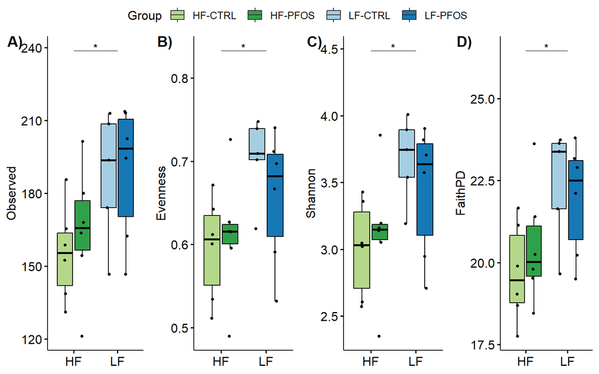

```
##
## $Observed
## $Observed$fit
## Call:
##    aov(formula = as.formula(paste(i, "~", OUTER.VAR, "*", INNER.VAR,
##     sep = " ")), data = adat)
##
## Terms:
##                      feed feed_treat Residuals
## Sum of Squares   4506.639    274.903 12361.916
## Deg. of Freedom         1          2        19
##
## Residual standard error: 25.50739
## 4 out of 8 effects not estimable
## Estimated effects may be unbalanced
##
## $Observed$ANOVA
## Analysis of Variance Table
##
## Response: Observed
##            Df  Sum Sq Mean Sq F value  Pr(>F)
## feed        1  4506.6  4506.6  6.9266 0.01643 *
## feed_treat  2   274.9   137.5  0.2113 0.81144
## Residuals  19 12361.9   650.6
## ---
## Signif. codes:  0 '***' 0.001 '**' 0.01 '*' 0.05 '.' 0.1 ' ' 1
##
## $Observed$TukeyHSD
##   Tukey multiple comparisons of means
##     95% family-wise confidence level
##
## Fit: aov(formula = as.formula(paste(i, "~", OUTER.VAR, "*", INNER.VAR, sep = " ")), data = adat)
##
## $feed
##           diff      lwr      upr     p adj
## LF-HF 28.02227 5.737037 50.30751 0.0164279
##
## $feed_treat
##                      diff       lwr      upr     p adj
## HF_PFOS-HF_CTRL  9.446667 -31.96255 50.85588 0.9172073
```

[output cut: 131 more lines]

```
##
## Fit: aov(formula = as.formula(paste(i, "~", OUTER.VAR, "*", INNER.VAR, sep = " ")), data = adat)
##
## $feed
##           diff       lwr      upr     p adj
## LF-HF 2.058797 0.5751864 3.542408 0.0090888
##
## $feed_treat
##                       diff       lwr      upr     p adj
## HF_PFOS-HF_CTRL  0.8110170 -1.945748 3.567782 0.8408996
## LF_CTRL-HF_CTRL  0.6568324 -2.234487 3.548152 0.9181280
## LF_PFOS-HF_CTRL  0.1960719 -2.560693 2.952837 0.9970666
## LF_CTRL-HF_PFOS -0.1541846 -3.045504 2.737135 0.9987542
## LF_PFOS-HF_PFOS -0.6149451 -3.371710 2.141820 0.9220213
## LF_PFOS-LF_CTRL -0.4607605 -3.352080 2.430559 0.9691931
```

```r
# Run alpha-diversity analysis and create output data with plot
adiv_output(INNER.VAR, OUTER.VAR, MTRL, DAY)
```

```r
# clear the environment and release memory
rm(list = ls(all.names = TRUE)[ls(all.names = TRUE) != "params"])
invisible(gc())
```

### 5.1.10 Cecum day 21

```r
# Load parameters and scripts
params <- readRDS("R_objects/Adiv_params.RDS")
load("scripts/adiv.Rdata")

# Set variables for subset analysis
INNER.VAR <- "feed_treat"
OUTER.VAR <- "feed"
MTRL <- "Cecum"
DAY <- "d21"

# Test batch effect for subset
adiv_batch_effect(INNER.VAR, OUTER.VAR, MTRL, DAY)
```

```
## [[1]]
##     feed
##      HF LF
##   c1  2  3
##   c2  6  5
##   c3  3  3
##   c4  1  1
##
## [[2]]
##     feed
##             HF        LF
##   c1 16.666667 25.000000
##   c2 50.000000 41.666667
##   c3 25.000000 25.000000
##   c4  8.333333  8.333333
##
## [[3]]
## # A tibble: 1 × 6
##       n statistic     p    df method          p.signif
## * <int>     <dbl> <dbl> <int> <chr>           <chr>
## 1    24     0.291 0.962     3 Chi-square test ns
```

```
## # A tibble: 2 × 16
##   feed  .y.      group1  group2     n1    n2 statistic     p p.adj p.adj.signif
## * <fct> <chr>    <chr>   <chr>   <int> <int>     <dbl> <dbl> <dbl> <chr>
## 1 HF    Observed HF_CTRL HF_PFOS     6     6        17 0.937 0.937 ns
## 2 LF    Observed LF_CTRL LF_PFOS     6     6         5 0.041 0.082 ns
## # ℹ 6 more variables: y.position <dbl>, groups <named list>, x <dbl>,
## #   xmin <dbl>, xmax <dbl>, p.adj.format <chr>
## # A tibble: 1 × 14
##   .y.      group1 group2    n1    n2 statistic      p  p.adj p.adj.signif
## * <chr>    <chr>  <chr>  <int> <int>     <dbl>  <dbl>  <dbl> <chr>
## 1 Observed HF     LF        12    12        36 0.0387 0.0387 *
## # ℹ 5 more variables: y.position <dbl>, groups <named list>, xmin <dbl>,
## #   xmax <dbl>, p.adj.format <chr>
## # A tibble: 2 × 16
##   feed  .y.      group1  group2     n1    n2 statistic     p p.adj p.adj.signif
## * <fct> <chr>    <chr>   <chr>   <int> <int>     <dbl> <dbl> <dbl> <chr>
## 1 HF    Evenness HF_CTRL HF_PFOS     6     6        21 0.699 0.699 ns
## 2 LF    Evenness LF_CTRL LF_PFOS     6     6         9 0.18  0.36  ns
## # ℹ 6 more variables: y.position <dbl>, groups <named list>, x <dbl>,
## #   xmin <dbl>, xmax <dbl>, p.adj.format <chr>
## # A tibble: 1 × 14
##   .y.      group1 group2    n1    n2 statistic       p   p.adj p.adj.signif
## * <chr>    <chr>  <chr>  <int> <int>     <dbl>   <dbl>   <dbl> <chr>
## 1 Evenness HF     LF        12    12        27 0.00829 0.00829 **
## # ℹ 5 more variables: y.position <dbl>, groups <named list>, xmin <dbl>,
## #   xmax <dbl>, p.adj.format <chr>
## # A tibble: 2 × 16
##   feed  .y.     group1  group2     n1    n2 statistic     p p.adj p.adj.signif
## * <fct> <chr>   <chr>   <chr>   <int> <int>     <dbl> <dbl> <dbl> <chr>
## 1 HF    Shannon HF_CTRL HF_PFOS     6     6        20 0.818 0.818 ns
## 2 LF    Shannon LF_CTRL LF_PFOS     6     6         8 0.132 0.264 ns
## # ℹ 6 more variables: y.position <dbl>, groups <named list>, x <dbl>,
## #   xmin <dbl>, xmax <dbl>, p.adj.format <chr>
## # A tibble: 1 × 14
##   .y.     group1 group2    n1    n2 statistic       p   p.adj p.adj.signif
## * <chr>   <chr>  <chr>  <int> <int>     <dbl>   <dbl>   <dbl> <chr>
## 1 Shannon HF     LF        12    12        27 0.00829 0.00829 **
## # ℹ 5 more variables: y.position <dbl>, groups <named list>, xmin <dbl>,
## #   xmax <dbl>, p.adj.format <chr>
## # A tibble: 2 × 16
##   feed  .y.     group1  group2     n1    n2 statistic     p p.adj p.adj.signif
## * <fct> <chr>   <chr>   <chr>   <int> <int>     <dbl> <dbl> <dbl> <chr>
## 1 HF    FaithPD HF_CTRL HF_PFOS     6     6        18 1      1    ns
## 2 LF    FaithPD LF_CTRL LF_PFOS     6     6         3 0.015  0.03 *
## # ℹ 6 more variables: y.position <dbl>, groups <named list>, x <dbl>,
## #   xmin <dbl>, xmax <dbl>, p.adj.format <chr>
## # A tibble: 1 × 14
##   .y.     group1 group2    n1    n2 statistic      p  p.adj p.adj.signif
## * <chr>   <chr>  <chr>  <int> <int>     <dbl>  <dbl>  <dbl> <chr>
## 1 FaithPD HF     LF        12    12        42 0.0887 0.0887 ns
## # ℹ 5 more variables: y.position <dbl>, groups <named list>, xmin <dbl>,
## #   xmax <dbl>, p.adj.format <chr>
```

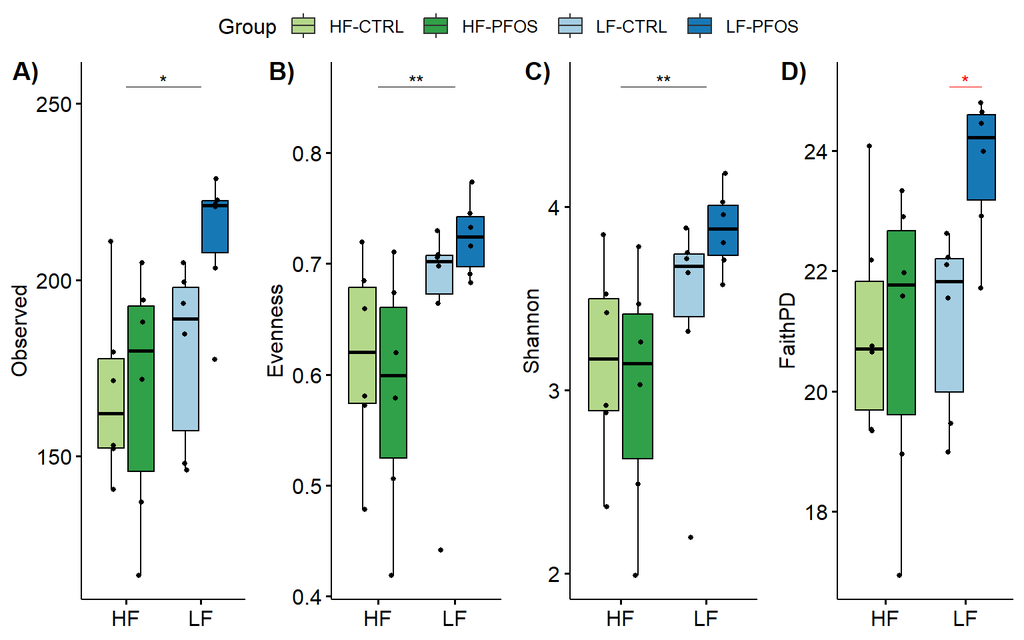

```
##
## $Observed
## $Observed$fit
## Call:
##    aov(formula = as.formula(paste(i, "~", OUTER.VAR, "*", INNER.VAR,
##     sep = " ")), data = adat)
##
## Terms:
##                      feed feed_treat Residuals
## Sum of Squares   4552.087   3275.209 14507.973
## Deg. of Freedom         1          2        20
##
## Residual standard error: 26.93323
## 4 out of 8 effects not estimable
## Estimated effects may be unbalanced
##
## $Observed$ANOVA
## Analysis of Variance Table
##
## Response: Observed
##            Df  Sum Sq Mean Sq F value  Pr(>F)
## feed        1  4552.1  4552.1  6.2753 0.02101 *
## feed_treat  2  3275.2  1637.6  2.2575 0.13061
## Residuals  20 14508.0   725.4
## ---
## Signif. codes:  0 '***' 0.001 '**' 0.01 '*' 0.05 '.' 0.1 ' ' 1
##
## $Observed$TukeyHSD
##   Tukey multiple comparisons of means
##     95% family-wise confidence level
##
## Fit: aov(formula = as.formula(paste(i, "~", OUTER.VAR, "*", INNER.VAR, sep = " ")), data = adat)
##
## $feed
##           diff      lwr      upr     p adj
## LF-HF 27.54417 4.608075 50.48026 0.0210056
##
## $feed_treat
##                        diff       lwr      upr     p adj
## HF_PFOS-HF_CTRL   0.7316667 -42.79153 44.25486 0.9999612
```

[output cut: 131 more lines]

```
##
## Fit: aov(formula = as.formula(paste(i, "~", OUTER.VAR, "*", INNER.VAR, sep = " ")), data = adat)
##
## $feed
##           diff        lwr      upr     p adj
## LF-HF 1.454821 -0.1008651 3.010507 0.0652437
##
## $feed_treat
##                       diff        lwr      upr     p adj
## HF_PFOS-HF_CTRL -0.1162429 -3.0682896 2.835804 0.9995040
## LF_CTRL-HF_CTRL -1.3546414 -4.3066881 1.597405 0.5829203
## LF_PFOS-HF_CTRL  1.2383985 -1.7136482 4.190445 0.6494439
## LF_CTRL-HF_PFOS -1.2383985 -4.1904452 1.713648 0.6494439
## LF_PFOS-HF_PFOS  1.3546414 -1.5974053 4.306688 0.5829203
## LF_PFOS-LF_CTRL  2.5930399 -0.3590068 5.545087 0.0979578
```

```r
# Run alpha-diversity analysis and create output data with plot
adiv_output(INNER.VAR, OUTER.VAR, MTRL, DAY)
```

```r
#INNER.VAR = "feed_treat", OUTER.VAR = "feed", MTRL = "Feces", DAY = "d08"

# clear the environment and release memory
rm(list = ls(all.names = TRUE)[ls(all.names = TRUE) != "params"])
invisible(gc())
```

## 5.2 Diversity plot with rats group-wise over time

Here we look at all data in one figure per metric. The first code-chunk is processing data and analysing which statistical analysis to use for each metric. The plots contain longitudinal faecal data from each rat along with summary of each treatment group per day as boxplots.

### 5.2.1 Prepare data

```
## [1] "Processing Observed"
## # A tibble: 3 × 77
##   feed_treat_day Sample Project Seq_run reads  ASVs SampleID  is.neg type
##   <chr>          <chr>  <chr>   <chr>   <dbl> <dbl> <chr>     <lgl>  <chr>
## 1 12_LF_PFOS     F12R19 fibrex  c1      18556   202 c1_F12R19 FALSE  Sample
## 2 12_LF_PFOS     F12R23 fibrex  c2      61776   328 c2_F12R23 FALSE  Sample
## 3 16_HF_CTRL     F16R35 fibrex  c4      73178   206 c4_F16R35 FALSE  Sample
## # ℹ 68 more variables: Sample_ID <chr>, sample_name <chr>, barcode <chr>,
## #   fwd_primer <chr>, pcr_tag <int>, extract_tag <chr>, rat_no <int>,
## #   rat_org <chr>, rat_name <chr>, material <chr>, sample_type <chr>,
## #   day_no <int>, day <chr>, dissection <chr>, sub_gr <chr>, feed <chr>,
## #   feed_name <chr>, treatment <chr>, feed_treat <chr>, materialdayrat <chr>,
## #   carmin <chr>, extract_batch <int>, plate_location <chr>, Run <chr>,
## #   dna_conc <dbl>, note <chr>, bw <dbl>, cecum_weight <dbl>, …
## # A tibble: 20 × 4
##    feed_treat_day variable statistic      p
##    <chr>          <chr>        <dbl>  <dbl>
##  1 0_HF_CTRL      Observed     0.971 0.923
##  2 0_HF_PFOS      Observed     0.924 0.322
##  3 0_LF_CTRL      Observed     0.923 0.311
##  4 0_LF_PFOS      Observed     0.929 0.365
##  5 12_HF_CTRL     Observed     0.951 0.752
##  6 12_HF_PFOS     Observed     0.970 0.894
##  7 12_LF_CTRL     Observed     0.800 0.0585
##  8 12_LF_PFOS     Observed     0.947 0.720
##  9 16_HF_CTRL     Observed     0.969 0.883
## 10 16_HF_PFOS     Observed     0.917 0.484
## 11 16_LF_CTRL     Observed     0.947 0.712
## 12 16_LF_PFOS     Observed     0.957 0.797
## 13 21_HF_CTRL     Observed     0.813 0.0771
## 14 21_HF_PFOS     Observed     0.892 0.329
## 15 21_LF_CTRL     Observed     0.932 0.596
## 16 21_LF_PFOS     Observed     0.816 0.0807
## 17 8_HF_CTRL      Observed     0.901 0.161
## 18 8_HF_PFOS      Observed     0.919 0.276
## 19 8_LF_CTRL      Observed     0.986 0.998
## 20 8_LF_PFOS      Observed     0.891 0.121
```

```
## # A tibble: 1 × 4
##     df1   df2 statistic      p
##   <int> <int>     <dbl>  <dbl>
## 1    19   148      1.74 0.0354
```

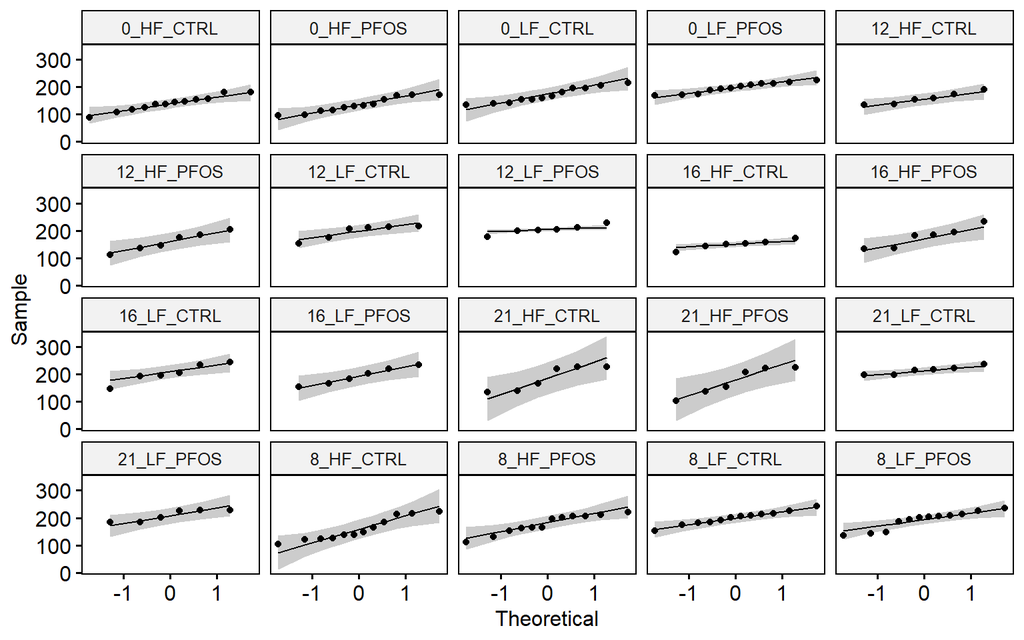

```
## [1] "Equal variance for Observed = FALSE"
## [1] "Processing Evenness"
## # A tibble: 10 × 77
##    feed_treat_day Sample Project Seq_run reads  ASVs SampleID  is.neg type
##    <chr>          <chr>  <chr>   <chr>   <dbl> <dbl> <chr>     <lgl>  <chr>
##  1 0_HF_CTRL      F0R28  fibrex  c1      35771   212 c1_F0R28  FALSE  Sample
##  2 0_HF_CTRL      F0R36  fibrex  c1      31749   121 c1_F0R36  FALSE  Sample
##  3 0_LF_CTRL      F0R07  fibrex  c1      45221   195 c1_F0R07  FALSE  Sample
##  4 0_LF_PFOS      F0R21  fibrex  c3      39706   260 c3_F0R21  FALSE  Sample
##  5 12_HF_CTRL     F12R33 fibrex  c1      48662   227 c1_F12R33 FALSE  Sample
##  6 12_HF_CTRL     F12R32 fibrex  c3      59499   279 c3_F12R32 FALSE  Sample
##  7 16_HF_PFOS     F16R45 fibrex  c2      62908   326 c2_F16R45 FALSE  Sample
##  8 16_HF_PFOS     F16R48 fibrex  c2      65772   200 c2_F16R48 FALSE  Sample
##  9 21_LF_CTRL     F21R08 fibrex  c4      69227   307 c4_F21R08 FALSE  Sample
## 10 8_LF_PFOS      F8R17  fibrex  c1      28723   183 c1_F8R17  FALSE  Sample
```

[output cut: 30 more lines]

```
## # A tibble: 1 × 4
##     df1   df2 statistic     p
##   <int> <int>     <dbl> <dbl>
## 1    19   148      1.36 0.156
```

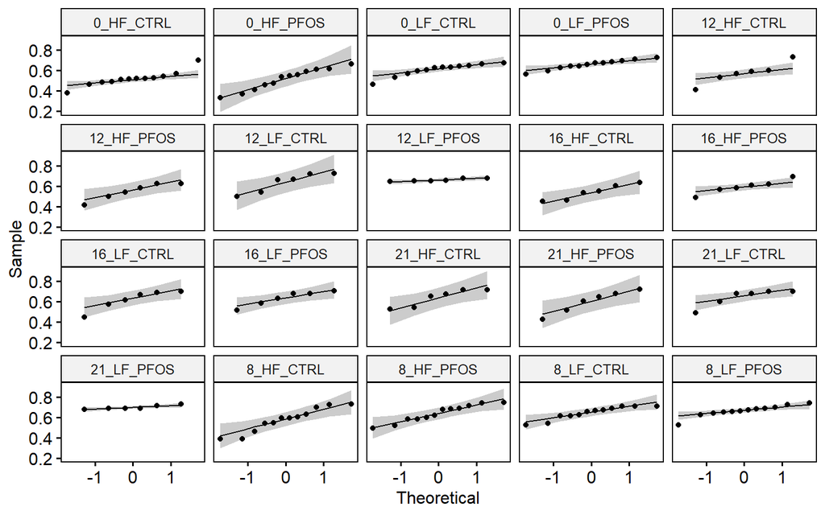

```
## [1] "Equal variance for Evenness = TRUE"
## [1] "Processing Shannon"
## # A tibble: 9 × 77
##   feed_treat_day Sample Project Seq_run  reads  ASVs SampleID  is.neg type
##   <chr>          <chr>  <chr>   <chr>    <dbl> <dbl> <chr>     <lgl>  <chr>
## 1 0_HF_CTRL      F0R28  fibrex  c1       35771   212 c1_F0R28  FALSE  Sample
## 2 0_HF_CTRL      F0R36  fibrex  c1       31749   121 c1_F0R36  FALSE  Sample
## 3 0_LF_CTRL      F0R07  fibrex  c1       45221   195 c1_F0R07  FALSE  Sample
## 4 12_HF_CTRL     F12R32 fibrex  c3       59499   279 c3_F12R32 FALSE  Sample
## 5 12_LF_PFOS     F12R20 fibrex  c3       61537   289 c3_F12R20 FALSE  Sample
## 6 21_LF_CTRL     F21R08 fibrex  c4       69227   307 c4_F21R08 FALSE  Sample
## 7 21_LF_PFOS     F21R23 fibrex  c1       18224   211 c1_F21R23 FALSE  Sample
## 8 21_LF_PFOS     F21R22 fibrex  c3      106912   332 c3_F21R22 FALSE  Sample
## 9 8_LF_PFOS      F8R17  fibrex  c1       28723   183 c1_F8R17  FALSE  Sample
## # ℹ 68 more variables: Sample_ID <chr>, sample_name <chr>, barcode <chr>,
```

[output cut: 29 more lines]

```
## # A tibble: 1 × 4
##     df1   df2 statistic      p
##   <int> <int>     <dbl>  <dbl>
## 1    19   148      1.64 0.0529
```

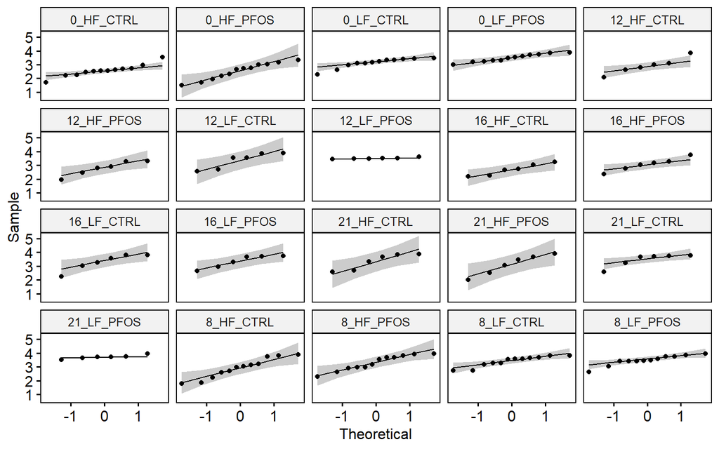

```
## [1] "Equal variance for Shannon = TRUE"
## [1] "Processing FaithPD"
## # A tibble: 2 × 77
##   feed_treat_day Sample Project Seq_run reads  ASVs SampleID  is.neg type
##   <chr>          <chr>  <chr>   <chr>   <dbl> <dbl> <chr>     <lgl>  <chr>
## 1 16_HF_CTRL     F16R35 fibrex  c4      73178   206 c4_F16R35 FALSE  Sample
## 2 8_LF_PFOS      F8R22  fibrex  c1      43784   183 c1_F8R22  FALSE  Sample
## # ℹ 68 more variables: Sample_ID <chr>, sample_name <chr>, barcode <chr>,
## #   fwd_primer <chr>, pcr_tag <int>, extract_tag <chr>, rat_no <int>,
## #   rat_org <chr>, rat_name <chr>, material <chr>, sample_type <chr>,
## #   day_no <int>, day <chr>, dissection <chr>, sub_gr <chr>, feed <chr>,
## #   feed_name <chr>, treatment <chr>, feed_treat <chr>, materialdayrat <chr>,
## #   carmin <chr>, extract_batch <int>, plate_location <chr>, Run <chr>,
## #   dna_conc <dbl>, note <chr>, bw <dbl>, cecum_weight <dbl>, …
## # A tibble: 20 × 4
##    feed_treat_day variable statistic     p
##    <chr>          <chr>        <dbl> <dbl>
##  1 0_HF_CTRL      FaithPD      0.970 0.914
##  2 0_HF_PFOS      FaithPD      0.896 0.141
##  3 0_LF_CTRL      FaithPD      0.911 0.217
##  4 0_LF_PFOS      FaithPD      0.964 0.840
##  5 12_HF_CTRL     FaithPD      0.930 0.577
##  6 12_HF_PFOS     FaithPD      0.982 0.962
##  7 12_LF_CTRL     FaithPD      0.879 0.265
##  8 12_LF_PFOS     FaithPD      0.916 0.478
##  9 16_HF_CTRL     FaithPD      0.912 0.453
## 10 16_HF_PFOS     FaithPD      0.917 0.482
## 11 16_LF_CTRL     FaithPD      0.958 0.806
## 12 16_LF_PFOS     FaithPD      0.932 0.597
## 13 21_HF_CTRL     FaithPD      0.853 0.165
## 14 21_HF_PFOS     FaithPD      0.870 0.226
## 15 21_LF_CTRL     FaithPD      0.952 0.755
## 16 21_LF_PFOS     FaithPD      0.936 0.625
## 17 8_HF_CTRL      FaithPD      0.901 0.165
## 18 8_HF_PFOS      FaithPD      0.896 0.142
## 19 8_LF_CTRL      FaithPD      0.971 0.924
## 20 8_LF_PFOS      FaithPD      0.906 0.190
```

```
## # A tibble: 1 × 4
##     df1   df2 statistic     p
##   <int> <int>     <dbl> <dbl>
## 1    19   148      1.32 0.176
```

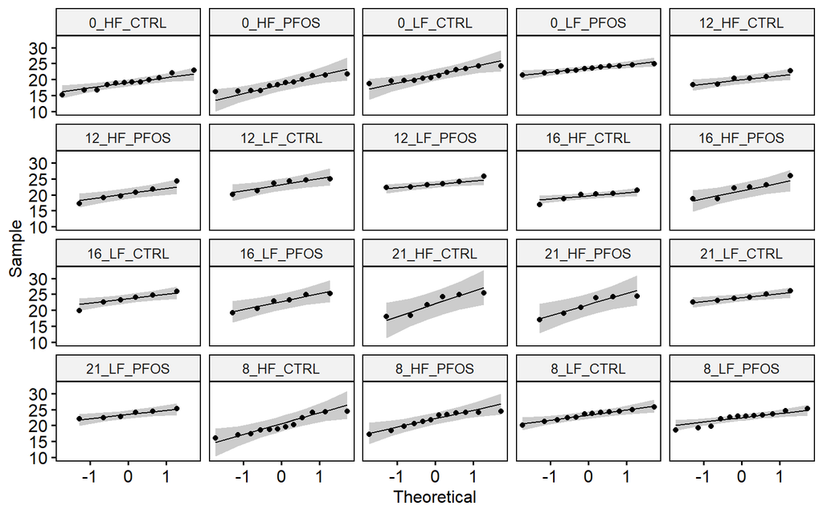

```
## [1] "Equal variance for FaithPD = TRUE"
```

```r
params <- readRDS("R_objects/Adiv_params.RDS")

# Load data
load("R_objects/Phyloseq.Rdata")

# Extract sample data and alpha diversity
adat <- as_tibble(sample_data(phy))

# Subset and order data
tmp <- adat[adat$material == "Feces" & adat$day != "d20",]
tmp <- tmp[order(tmp$day),]

# Add column
rats <- unique(tmp$rat_name)

# NORMALISED ADIV PLOT FOR RATS + TREATMENT OVER TIME (NORMALISED)
for (rat in rats){
  tmp$Observed_norm[tmp$rat_name == rat] <- tmp$Observed[tmp$rat_name == rat]/tmp$Observed[tmp$rat_name == rat & tmp$day == "d0"]
  tmp$Shannon_norm[tmp$rat_name == rat] <- tmp$Shannon[tmp$rat_name == rat]/tmp$Shannon[tmp$rat_name == rat & tmp$day == "d0"]
  tmp$Evenness_norm[tmp$rat_name == rat] <- tmp$Evenness[tmp$rat_name == rat]/tmp$Evenness[tmp$rat_name == rat & tmp$day == "d0"]
  tmp$FaithPD_norm[tmp$rat_name == rat] <- tmp$FaithPD[tmp$rat_name == rat]/tmp$FaithPD[tmp$rat_name == rat & tmp$day == "d0"]
}
# Set names of variables
PREDICTOR <- "feed_treat_day"#c("feed","treatment","day")
OCS <- c("Observed", "Evenness", "Shannon", "FaithPD")
OUTCOME <- "Observed"
SUBJECT <- "rat_name"

for (OUTCOME in OCS) {
print(paste0("Processing ",OUTCOME))
# Remove rows with NA
tmp <- subset(tmp, !is.na(OUTCOME))

# Will yoou run a paired test? (set variable to `TRUE` or `FALSE`)
PAIRED <- FALSE

# Create formula
FORMULA <- as.formula(paste(OUTCOME, PREDICTOR, sep = "~"))

# Sort data for paired test
if (PAIRED) {
  # Order data
  tmp <- arrange(tmp, !!sym(SUBJECT))

  # Remove unpaired samples
  tmp <- tmp %>%
    group_by(!!sym(SUBJECT)) %>%
    filter(n() != 1) %>%
    arrange(!!sym(PREDICTOR), !!sym(SUBJECT)) %>%
    droplevels() %>%
    ungroup()
}

# identify outliers
ol <- tmp %>%
  group_by(!!sym(PREDICTOR)) %>%
  identify_outliers(!!sym(OUTCOME))
print(ol)
# Run Shapiro test
st <- tmp %>%
  group_by(!!sym(PREDICTOR)) %>%
  shapiro_test(!!sym(OUTCOME))
print(st)
# Create QQplot
qq <- ggqqplot(tmp, x = OUTCOME, facet.by = PREDICTOR)
print(qq)
# Run test
lt <- tmp %>% levene_test(FORMULA)
print(lt)
# Save output
EQUAL.VAR <- tmp %>% levene_test(FORMULA) %>% pull(p) > 0.05
print(paste0("Equal variance for ",OUTCOME," = ",EQUAL.VAR))
}
```

### 5.2.2 Statistics and figure

Due to low sample count from day 12 and on (group n = 6) we will compare based on non-parametric Kruskal-Wallis with post hoc Dunn’s test. Comparison between diets on each day is done using non-parametric t-test (Wilcoxon).

```
## [1] "Processing Observed..."
## # A tibble: 4 × 9
##   feed_treat .y.          n statistic    df      p method      p.signif p.format
## * <chr>      <chr>    <int>     <dbl> <int>  <dbl> <chr>       <chr>    <chr>
## 1 HF_CTRL    Observed    42      4.71     4 0.318  Kruskal-Wa… ns       0.318
## 2 HF_PFOS    Observed    42      9.28     4 0.0545 Kruskal-Wa… ns       0.054
## 3 LF_CTRL    Observed    42     10.9      4 0.0277 Kruskal-Wa… *        0.028
## 4 LF_PFOS    Observed    42      1.34     4 0.855  Kruskal-Wa… ns       0.855
## # A tibble: 40 × 15
##    feed_treat .y.      group1 group2    n1    n2 statistic      p p.adj
##    <chr>      <chr>    <chr>  <chr>  <int> <int>     <dbl>  <dbl> <dbl>
##  1 HF_CTRL    Observed d0     d08       12    12    0.915  0.360  1
##  2 HF_CTRL    Observed d0     d12       12     6    1.14   0.254  1
##  3 HF_CTRL    Observed d0     d16       12     6    0.761  0.447  1
##  4 HF_CTRL    Observed d0     d21       12     6    2.12   0.0341 0.341
##  5 HF_CTRL    Observed d08    d12       12     6    0.394  0.694  1
##  6 HF_CTRL    Observed d08    d16       12     6    0.0136 0.989  1
##  7 HF_CTRL    Observed d08    d21       12     6    1.37   0.170  1
##  8 HF_CTRL    Observed d12    d16        6     6   -0.329  0.742  1
##  9 HF_CTRL    Observed d12    d21        6     6    0.847  0.397  1
## 10 HF_CTRL    Observed d16    d21        6     6    1.18   0.239  1
## # ℹ 30 more rows
## # ℹ 6 more variables: p.adj.signif <chr>, p.adj.format <chr>, y.position <dbl>,
## #   groups <named list>, xmin <dbl>, xmax <dbl>
```

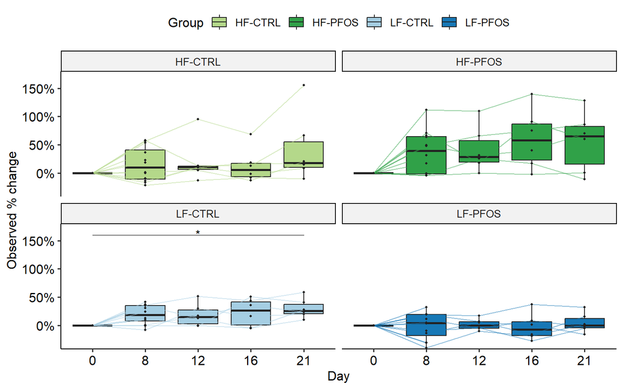

```
## [1] "Processing Evenness..."
## # A tibble: 4 × 9
##   feed_treat .y.          n statistic    df      p method      p.signif p.format
## * <chr>      <chr>    <int>     <dbl> <int>  <dbl> <chr>       <chr>    <chr>
## 1 HF_CTRL    Evenness    42      7.35     4 0.119  Kruskal-Wa… ns       0.119
## 2 HF_PFOS    Evenness    42      9.19     4 0.0565 Kruskal-Wa… ns       0.056
## 3 LF_CTRL    Evenness    42      3.44     4 0.487  Kruskal-Wa… ns       0.487
## 4 LF_PFOS    Evenness    42      6.56     4 0.161  Kruskal-Wa… ns       0.161
## # A tibble: 40 × 15
##    feed_treat .y.      group1 group2    n1    n2 statistic      p p.adj
##    <chr>      <chr>    <chr>  <chr>  <int> <int>     <dbl>  <dbl> <dbl>
##  1 HF_CTRL    Evenness d0     d08       12    12    1.78   0.0750 0.675
##  2 HF_CTRL    Evenness d0     d12       12     6    1.47   0.142  1
##  3 HF_CTRL    Evenness d0     d16       12     6    0.734  0.463  1
##  4 HF_CTRL    Evenness d0     d21       12     6    2.50   0.0124 0.124
##  5 HF_CTRL    Evenness d08    d12       12     6    0.0136 0.989  1
##  6 HF_CTRL    Evenness d08    d16       12     6   -0.720  0.472  1
##  7 HF_CTRL    Evenness d08    d21       12     6    1.05   0.296  1
##  8 HF_CTRL    Evenness d12    d16        6     6   -0.635  0.525  1
##  9 HF_CTRL    Evenness d12    d21        6     6    0.894  0.371  1
## 10 HF_CTRL    Evenness d16    d21        6     6    1.53   0.126  1
## # ℹ 30 more rows
## # ℹ 6 more variables: p.adj.signif <chr>, p.adj.format <chr>, y.position <dbl>,
## #   groups <named list>, xmin <dbl>, xmax <dbl>
```

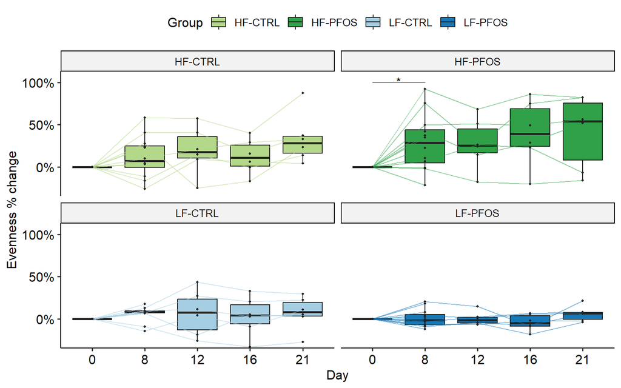

```
## [1] "Processing Shannon..."
## # A tibble: 4 × 9
##   feed_treat .y.         n statistic    df      p method       p.signif p.format
## * <chr>      <chr>   <int>     <dbl> <int>  <dbl> <chr>        <chr>    <chr>
## 1 HF_CTRL    Shannon    42      7.07     4 0.132  Kruskal-Wal… ns       0.13
## 2 HF_PFOS    Shannon    42      9.03     4 0.0604 Kruskal-Wal… ns       0.06
## 3 LF_CTRL    Shannon    42      5.47     4 0.242  Kruskal-Wal… ns       0.24
## 4 LF_PFOS    Shannon    42      4.81     4 0.308  Kruskal-Wal… ns       0.31
## # A tibble: 40 × 15
##    feed_treat .y.     group1 group2    n1    n2 statistic      p p.adj
##    <chr>      <chr>   <chr>  <chr>  <int> <int>     <dbl>  <dbl> <dbl>
##  1 HF_CTRL    Shannon d0     d08       12    12    1.65   0.0995 0.896
##  2 HF_CTRL    Shannon d0     d12       12     6    1.37   0.170  1
##  3 HF_CTRL    Shannon d0     d16       12     6    0.747  0.455  1
##  4 HF_CTRL    Shannon d0     d21       12     6    2.51   0.0120 0.120
##  5 HF_CTRL    Shannon d08    d12       12     6    0.0272 0.978  1
##  6 HF_CTRL    Shannon d08    d16       12     6   -0.598  0.550  1
##  7 HF_CTRL    Shannon d08    d21       12     6    1.17   0.243  1
##  8 HF_CTRL    Shannon d12    d16        6     6   -0.541  0.588  1
##  9 HF_CTRL    Shannon d12    d21        6     6    0.988  0.323  1
## 10 HF_CTRL    Shannon d16    d21        6     6    1.53   0.126  1
## # ℹ 30 more rows
## # ℹ 6 more variables: p.adj.signif <chr>, p.adj.format <chr>, y.position <dbl>,
## #   groups <named list>, xmin <dbl>, xmax <dbl>
```

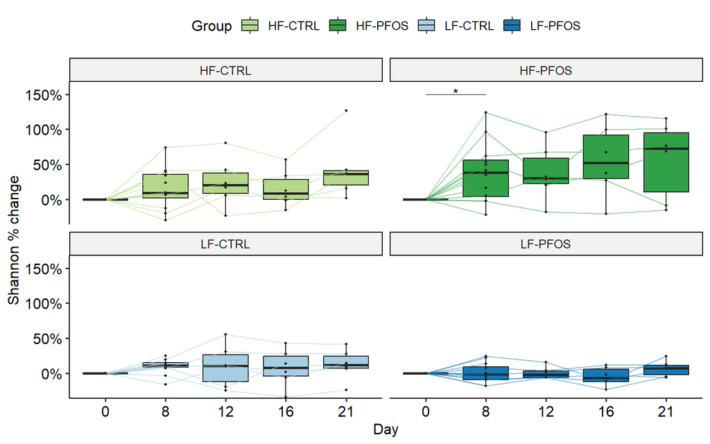

```
## [1] "Processing FaithPD..."
## # A tibble: 4 × 9
##   feed_treat .y.         n statistic    df      p method       p.signif p.format
## * <chr>      <chr>   <int>     <dbl> <int>  <dbl> <chr>        <chr>    <chr>
## 1 HF_CTRL    FaithPD    42      3.50     4 0.478  Kruskal-Wal… ns       0.478
## 2 HF_PFOS    FaithPD    42      9.88     4 0.0426 Kruskal-Wal… *        0.043
## 3 LF_CTRL    FaithPD    42      8.55     4 0.0734 Kruskal-Wal… ns       0.073
## 4 LF_PFOS    FaithPD    42      1.61     4 0.808  Kruskal-Wal… ns       0.808
## # A tibble: 40 × 15
##    feed_treat .y.     group1 group2    n1    n2 statistic      p p.adj
##    <chr>      <chr>   <chr>  <chr>  <int> <int>     <dbl>  <dbl> <dbl>
##  1 HF_CTRL    FaithPD d0     d08       12    12    0.732  0.464  1
##  2 HF_CTRL    FaithPD d0     d12       12     6    0.978  0.328  1
##  3 HF_CTRL    FaithPD d0     d16       12     6    0.571  0.568  1
##  4 HF_CTRL    FaithPD d0     d21       12     6    1.82   0.0687 0.687
##  5 HF_CTRL    FaithPD d08    d12       12     6    0.380  0.704  1
##  6 HF_CTRL    FaithPD d08    d16       12     6   -0.0272 0.978  1
##  7 HF_CTRL    FaithPD d08    d21       12     6    1.22   0.221  1
##  8 HF_CTRL    FaithPD d12    d16        6     6   -0.353  0.724  1
##  9 HF_CTRL    FaithPD d12    d21        6     6    0.729  0.466  1
## 10 HF_CTRL    FaithPD d16    d21        6     6    1.08   0.279  1
## # ℹ 30 more rows
## # ℹ 6 more variables: p.adj.signif <chr>, p.adj.format <chr>, y.position <dbl>,
## #   groups <named list>, xmin <dbl>, xmax <dbl>
```

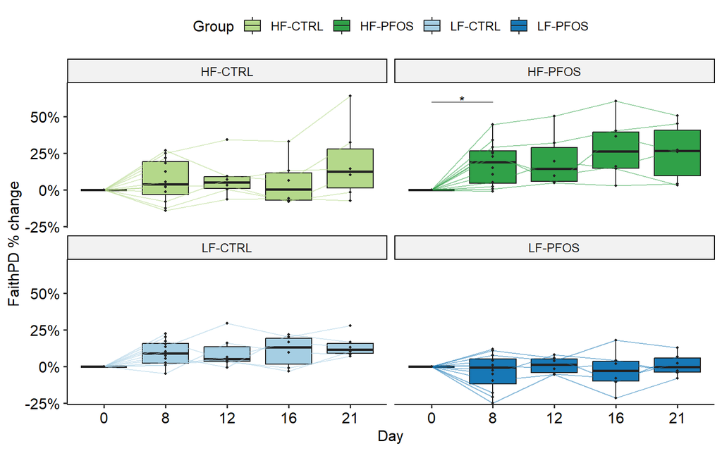

```r
# Run statistics and create plots for all metrices in OCS
for (OUTCOME in OCS) {
  print(paste0("Processing ",OUTCOME,"..."))
## Pairwise comparison for inner variable
  FORM.OUT <- paste0(OUTCOME," ~ day")
  stat.out <- tmp %>%
    group_by(feed_treat) %>%
    kruskal_test(formula = as.formula(FORM.OUT)) %>%
    add_significance() %>%
    p_format("p", accuracy = 0.001, trailing.zero = TRUE, new.col = TRUE)
  print(stat.out)

  pwc1 <- tmp %>%
    group_by(feed_treat) %>%
    dunn_test(formula = as.formula(FORM.OUT)) %>%
    add_significance() %>%
    p_format("p.adj", accuracy = 0.001, trailing.zero = TRUE, new.col = TRUE) %>%
    add_xy_position(x = "day")
  print(pwc1)

#Plot
p <- ggplot(tmp, aes(x=day, y = .data[[paste0(OUTCOME,"_norm")]])) +
  geom_boxplot(aes(fill = feed_treat), outlier.shape = NA, lwd=0.5, color = "#222222") +
  geom_line(aes(group = rat_name, color = feed_treat), alpha = 0.5) +
  geom_point(aes(fill = factor(feed_treat), color = factor(feed_treat)), shape = 21, stroke = NA, size = 1, fill = "#222222") + #, color = c("#222222","#222222","#222222","#222222")
  facet_wrap("feed_treat", nrow = 2, ncol = 2,, strip.position="top", labeller = labeller(feed_treat = c("LF_CTRL" = "LF-CTRL","LF_PFOS" = "LF-PFOS","HF_CTRL" = "HF-CTRL","HF_PFOS" = "HF-PFOS"))) +
  scale_color_manual(values = params$COL) +
  scale_fill_manual(name = "Group", values = params$COL, labels = c("HF_CTRL" = "HF-CTRL","HF_PFOS" = "HF-PFOS","LF_CTRL" = "LF-CTRL","LF_PFOS" = "LF-PFOS")) +
  guides(color = "none") +
  scale_x_discrete(name = "Day", breaks=c("d0","d08","d12","d16","d21"), labels=c("0","8","12","16","21")) +
  scale_y_continuous(name = paste0(OUTCOME," % change"), labels = function(x) paste0(x*100-100, "%"), expand = expansion(mult = c(0.01, 0.1))) +
  theme_pubr(legend = "top")
p
if (OUTCOME == "Observed") {
  p.obs <- p + stat_pvalue_manual(pwc1, label = "p.adj.signif", tip.length = 0, hide.ns = TRUE, y.position = 2.6)
  pT <- p.obs
} else if (OUTCOME == "Evenness") {
  p.eve <- p + stat_pvalue_manual(pwc1, label = "p.adj.signif", tip.length = 0, hide.ns = TRUE, y.position = 2)
  pT <- p.eve
} else if (OUTCOME == "Shannon") {
  p.sha <- p + stat_pvalue_manual(pwc1, label = "p.adj.signif", tip.length = 0, hide.ns = TRUE, y.position = 2.5)
  pT <- p.sha
} else if (OUTCOME == "FaithPD") {
  p.fpd <- p + stat_pvalue_manual(pwc1, label = "p.adj.signif", tip.length = 0, hide.ns = TRUE, y.position = 1.6)
  pT <- p.fpd
}

pT
print(pT)

ggsave(filename = paste0("plots/adiv/timeline/adiv_over_time_rats_",OUTCOME,"_group.png"), plot = pT, device = "png", units = "mm", width = 130, height = 180, dpi = 300)
ggsave(filename = paste0("plots/adiv/timeline/adiv_over_time_rats_",OUTCOME,"_group.pdf"), plot = pT, device = "pdf", units = "mm", width = 130, height = 180, dpi = 300)
}
```

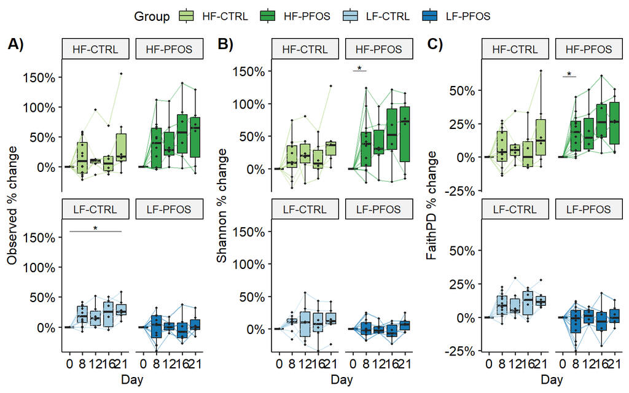

```r
p.all <- ggarrange(p.obs,p.sha,p.fpd, nrow = 1, labels = c("A)","B)","C)"), common.legend = TRUE,legend = "top")
p.all
```

```r
ggsave(filename = "plots/adiv/timeline/adiv_over_time_rats_group_all.png", plot = p.all, device = "png", units = "mm", width = 300, height = 150, dpi = 300)
ggsave(filename = "plots/adiv/timeline/adiv_over_time_rats_group_all.pdf", plot = p.all, device = "pdf", units = "mm", width = 300, height = 150, dpi = 300)

save(p.obs, p.eve, p.sha, p.fpd, p.all, file = "plots/adiv/timeline/adiv_figures.Rdata")
```

### 5.2.3 Conclusions

Based on current analysis, a significant increase in alpha-diversity was observed in Shannon index and FaithPD for HF-PFOS. A significant increase in LF-CTRL was observed over time, however, Day 0 signficant difference between LF-CTRL and LF-PFOS elutes conclusions from Day 0 to 8 for LF.

# 6 SETTINGS

Overview of the parameters and packages that were used for this analysis

## 6.1 PARAMETERS

The following paramenters were set in for this analysis:

```r
params <- readRDS("R_objects/Adiv_params.RDS")

tmp <- unlist(params)
dat <- data.frame(Parameter = names(tmp), Value = unname(tmp))


kbl(dat, row.names = F) %>% kable_classic(lightable_options = "striped")
```

| Parameter | Value |
| --- | --- |
| input | R_objects/Phyloseq.Rdata |
| batch | Run |
| indeces | Observed\|Evenness\|Shannon\|FaithPD |
| COL.LF_CTRL | #a5cee3 |
| COL.LF_PFOS | #1778b6 |
| COL.HF_CTRL | #b4d88a |
| COL.HF_PFOS | #30a148 |

## 6.2 PACKAGES

The analysis was run in R version 4.3.1 using the following packages:

```r
pack <- data.frame(Package = (.packages()))

for (i in seq(nrow(pack))) pack$Version[i] <- as.character(packageVersion(pack$Package[i]))

kbl(pack[order(pack$Package),], row.names = F) %>% kable_classic(lightable_options = "striped")
```

| Package | Version |
| --- | --- |
| ape | 5.8 |
| base | 4.3.1 |
| cowplot | 1.1.3 |
| datasets | 4.3.1 |
| dplyr | 1.1.4 |
| forcats | 1.0.0 |
| ggplot2 | 3.5.1 |
| ggpubr | 0.6.0 |
| graphics | 4.3.1 |
| grDevices | 4.3.1 |
| kableExtra | 1.4.0 |
| lattice | 0.21.8 |
| lubridate | 1.9.3 |
| methods | 4.3.1 |
| nlme | 3.1.162 |
| permute | 0.9.7 |
| phyloseq | 1.46.0 |
| picante | 1.8.2 |
| plotly | 4.10.4 |
| purrr | 1.0.2 |
| readr | 2.1.5 |
| rstatix | 0.7.2 |
| stats | 4.3.1 |
| stringr | 1.5.1 |
| tibble | 3.2.1 |
| tidyr | 1.3.1 |
| tidyverse | 2.0.0 |
| utils | 4.3.1 |
| vegan | 2.6.6.1 |